# data analysis: joint attention (BOSCA)

### 9.7.2 pupillary response as mediator

- for intervention model

```r
##causal mediation analysis
###--> only supports 1 level - one random intercept

df_trial$rpd_middle_z<-scale(df_trial$rpd_middle)
df_medanalysis<-df_trial[df_trial$t %in% c('T2','T6') & df_trial$rndm!='non autistic' & !is.na(df_trial$rpd_middle_z),]

glm_outcome<-glmer(rja_any~t*rndm+rpd_middle_z+
            (1|pic),
            data=df_medanalysis,family='binomial')

lmm_mod<-lme4::lmer(rpd_middle_z~t*rndm+
            (1|pic),data=df_medanalysis)

res<-mediation::mediate(lmm_mod,glm_outcome,
                        treat = 'rndm',
                        mediator='rpd_middle_z',
                        treat.value = 'autistic A-FFIP',
                        control.value = 'autistic TAU',
                        covariates = list(t = 'T6'), #check at FU2
                        sims=1000)

summary(res)
```

```
##
## Causal Mediation Analysis
##
## Quasi-Bayesian Confidence Intervals
##
## (Inference Conditional on the Covariate Values Specified in `covariates')
##
## Mediator Groups: pic
##
## Outcome Groups: pic
##
## Output Based on Overall Averages Across Groups
##
##                          Estimate 95% CI Lower 95% CI Upper p-value
## ACME (control)            0.00236     -0.00596         0.01    0.60
## ACME (treated)            0.00274     -0.00661         0.01    0.60
## ADE (control)             0.10208     -0.03999         0.25    0.16
## ADE (treated)             0.10246     -0.03961         0.25    0.16
## Total Effect              0.10481     -0.03780         0.25    0.15
## Prop. Mediated (control)  0.01364     -0.24550         0.37    0.64
## Prop. Mediated (treated)  0.01741     -0.23794         0.37    0.64
## ACME (average)            0.00255     -0.00630         0.01    0.60
## ADE (average)             0.10227     -0.03972         0.25    0.16
## Prop. Mediated (average)  0.01553     -0.24258         0.37    0.64
##
## Sample Size Used: 1035
##
##
## Simulations: 1000
```

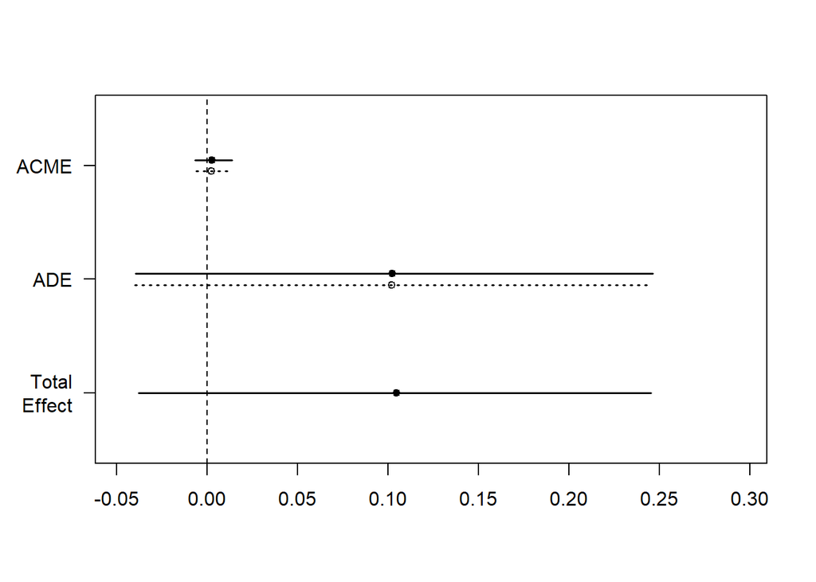

```r
plot(res)
```

- for development model –> did not converge

```r
##causal mediation analysis
###--> only supports 1 level - one random intercept

df_trial$rpd_middle_z<-scale(df_trial$rpd_middle)
df_medanalysis<-df_trial[df_trial$t %in% c('T2','FU2') & df_trial$rndm!='non autistic' & !is.na(df_trial$rpd_middle_z),]

glm_outcome<-glmer(rja_any~t*rndm+rpd_middle_z+
            (1|pic), data=df_medanalysis,family='binomial')

lmm_mod<-lme4::lmer(rpd_middle_z~t*rndm+
            (1|pic),data=df_medanalysis)

res<-mediation::mediate(lmm_mod,glm_outcome,
                        treat = 'rndm',
                        mediator='rpd_middle_z',
                        treat.value = 'autistic A-FFIP',
                        control.value = 'autistic TAU',
                        covariates = list(t = 'FU2'), #check at FU2
                        sims=1000)

#save(res,file=paste0(project_path,'/data/casual_mediation_SEPR.Rdata'))
load(paste0(project_path,'/data/casual_mediation_mediation_SEPR.Rdata'))
###--> saved and loaded as simulation can lead to different results between iterations

summary(res)
plot(res)
```

## 9.8 developmental cascades

- potential variables available at FU: IQ, SRS, RBS, CBCL
- key variables not available at FU: ADOS, BOSCC
- change in RJA likelihood from T2-T6 predicts change in SRS score from T2-FU2
- However, small sample size

### 9.8.1 create data set - wide format

```r
#data available for relevant data
with(demogr,table(!is.na(nonverbal_iq),t,rndm))
```

```
## , , rndm = autistic A-FFIP
##
##        t
##         T1 T2 T3 T4 T5 T6 FU FU2 FU3
##   FALSE  0 36  8 10 17 15 36  27  33
##   TRUE  36  0 28 26 19 21  0   9   3
##
## , , rndm = autistic TAU
##
##        t
##         T1 T2 T3 T4 T5 T6 FU FU2 FU3
##   FALSE  0 36  6 11 16 15 36  26  29
##   TRUE  36  0 30 25 20 21  0   8   7
##
## , , rndm = non autistic
##
##        t
##         T1 T2 T3 T4 T5 T6 FU FU2 FU3
##   FALSE  2 54 54 54 54 54 40  54  54
##   TRUE  52  0  0  0  0  0 14   0   0
```

```r
with(demogr,table(!is.na(verbal_iq),t,rndm))
```

```
## , , rndm = autistic A-FFIP
##
##        t
##         T1 T2 T3 T4 T5 T6 FU FU2 FU3
##   FALSE  4 36 36 36 36 18 36  32  34
##   TRUE  32  0  0  0  0 18  0   4   2
##
## , , rndm = autistic TAU
##
##        t
##         T1 T2 T3 T4 T5 T6 FU FU2 FU3
##   FALSE  3 35 36 36 36 15 36  30  34
##   TRUE  33  1  0  0  0 21  0   4   2
##
## , , rndm = non autistic
##
##        t
##         T1 T2 T3 T4 T5 T6 FU FU2 FU3
##   FALSE 53 54 54 54 54 54 44  54  54
##   TRUE   1  0  0  0  0  0 10   0   0
```

```r
with(demogr,table(!is.na(CBCL_T_GES),t,rndm))
```

```
## , , rndm = autistic A-FFIP
##
##        t
##         T1 T2 T3 T4 T5 T6 FU FU2 FU3
##   FALSE 36  2  9 12 17 19 36  23  30
##   TRUE   0 34 27 24 19 17  0  13   6
##
## , , rndm = autistic TAU
##
##        t
##         T1 T2 T3 T4 T5 T6 FU FU2 FU3
##   FALSE 36  8 11 16 19 16 36  26  29
##   TRUE   0 28 25 20 17 20  0   8   7
##
## , , rndm = non autistic
##
##        t
##         T1 T2 T3 T4 T5 T6 FU FU2 FU3
##   FALSE  2 54 54 54 54 54 30  54  54
##   TRUE  52  0  0  0  0  0 24   0   0
```

```r
with(demogr,table(!is.na(srs16_sum),t,rndm))
```

```
## , , rndm = autistic A-FFIP
##
##        t
##         T1 T2 T3 T4 T5 T6 FU FU2 FU3
##   FALSE 36  1  8 12 17 19 36  22  30
##   TRUE   0 35 28 24 19 17  0  14   6
##
## , , rndm = autistic TAU
##
##        t
##         T1 T2 T3 T4 T5 T6 FU FU2 FU3
##   FALSE 36  7  8 14 18 15 36  23  28
##   TRUE   0 29 28 22 18 21  0  11   8
##
## , , rndm = non autistic
##
##        t
##         T1 T2 T3 T4 T5 T6 FU FU2 FU3
##   FALSE  1 54 54 54 54 54 28  54  54
##   TRUE  53  0  0  0  0  0 26   0   0
```

```r
with(demogr,table(!is.na(RBSR_ges),t,rndm))
```

```
## , , rndm = autistic A-FFIP
##
##        t
##         T1 T2 T3 T4 T5 T6 FU FU2 FU3
##   FALSE 33  5  8 13 17 19 36  22  30
##   TRUE   3 31 28 23 19 17  0  14   6
##
## , , rndm = autistic TAU
##
##        t
##         T1 T2 T3 T4 T5 T6 FU FU2 FU3
##   FALSE 35  9  8 15 19 15 36  23  28
##   TRUE   1 27 28 21 17 21  0  11   8
##
## , , rndm = non autistic
##
##        t
##         T1 T2 T3 T4 T5 T6 FU FU2 FU3
##   FALSE  3 54 54 54 54 54 28  54  54
##   TRUE  51  0  0  0  0  0 26   0   0
```

```r
#add relevant variables to aggregated eye-tracking df
df_tmp<-dplyr::select(demogr,ID_Studie,t,nonverbal_iq,verbal_iq,CBCL_T_GES,srs16_sum,RBSR_ges)

table(df_tmp$t)
```

```
##
##  T1  T2  T3  T4  T5  T6  FU FU2 FU3
## 133 133 133 133 133 133 133 131 133
```

```r
table(df_et_agg$t)
```

```
##
##  T2  T4  T6 FU2 FU3
## 114  53  47  45  12
```

```r
df_et_cascades<-df_et_agg[,!names(df_et_agg) %in%
                       c('nonverbal_iq','verbal_iq','CBCL_T_GES','srs16_sum','RBSR_ges')]

df_et_cascades<-merge(df_et_cascades,df_tmp,by.x=c('pic','t'),by.y=c('ID_Studie','t'),all.x=T)
df_et_cascades<-df_et_cascades[,!names(df_et_cascades) %in% c('Group.1','Group.2')]

### varaiables for different groups are in different imepoints
### thus, some merging is required

#create data set for analysis
df_fu_measures_ASD<-df_et_cascades[df_et_cascades$t=='FU2' & df_et_cascades$rndm!='non autistic',names(df_et_cascades) %in% c('pic','rndm','nonverbal_iq','CBCL_T_GES','srs16_sum','RBSR_ges','verbal_iq')]

# non autistic follow-up data is labelled for a different timepoint:
df_fu_measures_TD<-demogr[demogr$t=='FU' & demogr$rndm=='non autistic',names(demogr) %in% c('ID_Studie','rndm','nonverbal_iq','CBCL_T_GES','srs16_sum','RBSR_ges','verbal_iq')]

names(df_fu_measures_ASD)<-c('pic','rndm',"nonverbal_iq_fu",'verbal_iq_fu',
                             "CBCL_T_GES_fu","srs16_sum_fu","RBSR_ges_fu")

names(df_fu_measures_TD)<-c('pic','rndm',"CBCL_T_GES_fu",
                            "srs16_sum_fu","RBSR_ges_fu",'verbal_iq_fu',"nonverbal_iq_fu")

df_fu_measures<-rbind(df_fu_measures_ASD,df_fu_measures_TD)
df_fu_measures<-df_fu_measures[!is.na(df_fu_measures$pic),]


df_bl_measures_ASD<-df_et_cascades[df_et_cascades$t=='T2'& df_et_cascades$rndm!='non autistic',
                          names(df_et_cascades) %in% c('pic','CBCL_T_GES','srs16_sum','RBSR_ges')]

df_bl_measures_TD<-demogr[demogr$t=='T1'& demogr$rndm=='non autistic',
                          names(demogr) %in% c('ID_Studie','CBCL_T_GES','srs16_sum','RBSR_ges')]

names(df_bl_measures_ASD)<-c('pic',"CBCL_T_GES_bl","srs16_sum_bl","RBSR_ges_bl")
names(df_bl_measures_TD)<-c('pic',"CBCL_T_GES_bl","srs16_sum_bl","RBSR_ges_bl")
df_bl_measures<-rbind(df_bl_measures_ASD,df_bl_measures_TD)

#get IQ baseline data
df_bl_measures_iq<-demogr[demogr$t=='T1',names(demogr) %in% c('ID_Studie','nonverbal_iq','verbal_iq')]
names(df_bl_measures_iq)<-c('pic',"verbal_iq_bl","nonverbal_iq_bl")

#get IQ T6 (end of intervention) data
df_t6_measures_iq<-demogr[demogr$t=='T6',names(demogr) %in% c('ID_Studie','nonverbal_iq','verbal_iq')]
names(df_t6_measures_iq)<-c('pic',"verbal_iq_t6","nonverbal_iq_t6")


#get RJA data at different imepoints
df_fu_rja<-df_et_cascades[df_et_cascades$t=='FU2',
                          names(df_et_cascades) %in% c('pic','rja_duration',
                                                                     'rja_any',
                                                                     'rja_occurances',
                                                                     'gazeduration_head',
                                                                     'time_to_target')]

df_t6_rja<-df_et_cascades[df_et_cascades$t=='T6',
                          names(df_et_cascades) %in% c('pic','rja_duration',
                                                                     'rja_any',
                                                                     'rja_occurances',
                                                                     'gazeduration_head',
                                                                     'time_to_target')]

df_t2_rja<-df_et_cascades[df_et_cascades$t=='T2',
                          names(df_et_cascades) %in% c('pic','rja_duration',
                                                                     'rja_any',
                                                                     'rja_occurances',
                                                                     'gazeduration_head',
                                                                     'time_to_target')]


names(df_fu_rja)<-c('pic',"time_to_target_fu","gazeduration_head_fu","rja_duration_fu",
                    "rja_any_fu","rja_occurances_fu")

names(df_t6_rja)<-c('pic',"time_to_target_t6","gazeduration_head_t6","rja_duration_t6",
                    "rja_any_t6","rja_occurances_t6")

names(df_t2_rja)<-c('pic',"time_to_target_t2","gazeduration_head_t2","rja_duration_t2",
                    "rja_any_t2","rja_occurances_t2")


#get pupillometry measures at timepoints
df_fu_pd<-df_et_cascades[df_et_cascades$t=='FU2',
                          names(df_et_cascades) %in% c('pic','baseline_pd',
                                                                     'rpd_middle')]

df_t6_pd<-df_et_cascades[df_et_cascades$t=='T6',
                          names(df_et_cascades) %in% c('pic','baseline_pd',
                                                                     'rpd_middle')]

df_t2_pd<-df_et_cascades[df_et_cascades$t=='T2',
                          names(df_et_cascades) %in% c('pic','baseline_pd',
                                                                     'rpd_middle')]


names(df_fu_pd)<-c('pic',"baseline_pd_fu","rpd_middle_fu")
names(df_t6_pd)<-c('pic',"baseline_pd_t6","rpd_middle_t6")
names(df_t2_pd)<-c('pic',"baseline_pd_t2","rpd_middle_t2")


#--> merge all
df_cascades<-merge(df_fu_measures,df_bl_measures,by='pic')
df_cascades<-merge(df_cascades,df_bl_measures_iq,by='pic')
df_cascades<-merge(df_cascades,df_t6_measures_iq,by='pic')
df_cascades$pic<-gsub('_K','',df_cascades$pic) #fix PIC

df_cascades<-merge(df_cascades,df_fu_rja,by='pic',all.x = T)
df_cascades<-merge(df_cascades,df_t6_rja,by='pic',all.x = T)
df_cascades<-merge(df_cascades,df_t2_rja,by='pic',all.x = T)

df_cascades<-merge(df_cascades,df_fu_pd,by='pic',all.x = T)
df_cascades<-merge(df_cascades,df_t6_pd,by='pic',all.x = T)
df_cascades<-merge(df_cascades,df_t2_pd,by='pic',all.x = T)


##create difference measures
df_cascades$srs16_sum_diff_t2fu<-df_cascades$srs16_sum_fu-df_cascades$srs16_sum_bl
df_cascades$RBSR_ges_diff_t2fu<-df_cascades$RBSR_ges_fu-df_cascades$RBSR_ges_bl
df_cascades$nonverbal_iq_diff_t2fu<-df_cascades$nonverbal_iq_fu-df_cascades$nonverbal_iq_bl

df_cascades$rja_any_diff_t2t6<-df_cascades$rja_any_t6-df_cascades$rja_any_t2
df_cascades$rja_any_diff_t6fu<-df_cascades$rja_any_fu-df_cascades$rja_any_t6
df_cascades$rja_any_diff_fu_t2fu<-df_cascades$rja_any_fu-df_cascades$rja_any_t2

df_cascades$baseline_pd_diff_t2t6<-df_cascades$baseline_pd_t6-df_cascades$baseline_pd_t2
df_cascades$baseline_pd_diff_t6fu<-df_cascades$baseline_pd_fu-df_cascades$rja_any_t6
df_cascades$baseline_pd_diff_t2fu<-df_cascades$baseline_pd_fu-df_cascades$baseline_pd_t2

df_cascades$rpd_middle_diff_t2t6<-df_cascades$rpd_middle_t6-df_cascades$rpd_middle_t2
df_cascades$rpd_middle_diff_t6fu<-df_cascades$rpd_middle_fu-df_cascades$rpd_middle_t2
df_cascades$rpd_middle_diff_t2fu<-df_cascades$rpd_middle_fu-df_cascades$rpd_middle_t2
```

## 9.9 developmental cascades analysis

```r
##association of developmental cascade measures and RJA change

summary(lm(scale(nonverbal_iq_diff_t2fu)~scale(rja_any_diff_t2t6),df_cascades))
```

```
##
## Call:
## lm(formula = scale(nonverbal_iq_diff_t2fu) ~ scale(rja_any_diff_t2t6),
##     data = df_cascades)
##
## Residuals:
##     Min      1Q  Median      3Q     Max
## -2.1805 -0.6598 -0.4493  0.8956  2.1167
##
## Coefficients:
##                          Estimate Std. Error t value Pr(>|t|)
## (Intercept)               0.05515    0.36980   0.149    0.884
## scale(rja_any_diff_t2t6)  0.25262    0.41715   0.606    0.557
##
## Residual standard error: 1.333 on 11 degrees of freedom
##   (59 observations deleted due to missingness)
## Multiple R-squared:  0.03226,    Adjusted R-squared:  -0.05571
## F-statistic: 0.3667 on 1 and 11 DF,  p-value: 0.5571
```

```r
summary(lm(scale(nonverbal_iq_diff_t2fu)~scale(baseline_pd_diff_t2t6),df_cascades))
```

```
##
## Call:
## lm(formula = scale(nonverbal_iq_diff_t2fu) ~ scale(baseline_pd_diff_t2t6),
##     data = df_cascades)
##
## Residuals:
##     Min      1Q  Median      3Q     Max
## -1.8558 -0.8770 -0.5335  1.0476  2.4028
##
## Coefficients:
##                              Estimate Std. Error t value Pr(>|t|)
## (Intercept)                   0.04256    0.35736   0.119    0.907
## scale(baseline_pd_diff_t2t6)  0.37490    0.34578   1.084    0.301
##
## Residual standard error: 1.288 on 11 degrees of freedom
##   (59 observations deleted due to missingness)
## Multiple R-squared:  0.09655,    Adjusted R-squared:  0.01442
## F-statistic: 1.176 on 1 and 11 DF,  p-value: 0.3015
```

```r
summary(lm(scale(nonverbal_iq_diff_t2fu)~scale(rpd_middle_diff_t2t6),df_cascades))
```

```
##
## Call:
## lm(formula = scale(nonverbal_iq_diff_t2fu) ~ scale(rpd_middle_diff_t2t6),
##     data = df_cascades)
##
## Residuals:
##     Min      1Q  Median      3Q     Max
## -1.7226 -1.0018 -0.1324  1.0349  2.4662
##
## Coefficients:
##                             Estimate Std. Error t value Pr(>|t|)
## (Intercept)                  0.03995    0.35100   0.114    0.911
## scale(rpd_middle_diff_t2t6)  0.43434    0.34095   1.274    0.229
##
## Residual standard error: 1.265 on 11 degrees of freedom
##   (59 observations deleted due to missingness)
## Multiple R-squared:  0.1286, Adjusted R-squared:  0.04934
## F-statistic: 1.623 on 1 and 11 DF,  p-value: 0.229
```

```r
df_cascades$rja_any_diff_t2t6_z<-scale(df_cascades$rja_any_diff_t2t6)
lm<-lm(scale(srs16_sum_diff_t2fu)~rja_any_diff_t2t6_z,df_cascades)
summary(lm)
```

```
##
## Call:
## lm(formula = scale(srs16_sum_diff_t2fu) ~ rja_any_diff_t2t6_z,
##     data = df_cascades)
##
## Residuals:
##      Min       1Q   Median       3Q      Max
## -1.92032 -1.04684  0.02659  0.80061  1.97715
##
## Coefficients:
##                     Estimate Std. Error t value Pr(>|t|)
## (Intercept)           0.2602     0.3814   0.682   0.5105
## rja_any_diff_t2t6_z  -1.2279     0.4207  -2.919   0.0153 *
## ---
## Signif. codes:  0 '***' 0.001 '**' 0.01 '*' 0.05 '.' 0.1 ' ' 1
##
## Residual standard error: 1.32 on 10 degrees of freedom
##   (60 observations deleted due to missingness)
## Multiple R-squared:   0.46,  Adjusted R-squared:  0.406
## F-statistic:  8.52 on 1 and 10 DF,  p-value: 0.01533
```

```r
confint(lm, 'rja_any_diff_t2t6_z', level=0.95)
```

```
##                         2.5 %     97.5 %
## rja_any_diff_t2t6_z -2.165266 -0.2905799
```

```r
with(df_cascades,table(is.na(srs16_sum_diff_t2fu),rndm))
```

```
##        rndm
##         autistic A-FFIP autistic TAU non autistic
##   FALSE               9            5           25
##   TRUE                0            4           29
```

```r
df_cascades$rja_any_t6_z<-scale(df_cascades$rja_any_t6)
lm<-lm(scale(srs16_sum_fu)~rja_any_t6_z+scale(rja_any_t2),data=df_cascades)
summary(lm)
```

```
##
## Call:
## lm(formula = scale(srs16_sum_fu) ~ rja_any_t6_z + scale(rja_any_t2),
##     data = df_cascades)
##
## Residuals:
##      Min       1Q   Median       3Q      Max
## -1.30601 -0.02957  0.08001  0.21650  0.70298
##
## Coefficients:
##                   Estimate Std. Error t value Pr(>|t|)
## (Intercept)         1.4902     0.2401   6.208 0.000157 ***
## rja_any_t6_z       -0.6641     0.2458  -2.701 0.024343 *
## scale(rja_any_t2)   0.6340     0.3417   1.856 0.096483 .
## ---
## Signif. codes:  0 '***' 0.001 '**' 0.01 '*' 0.05 '.' 0.1 ' ' 1
##
## Residual standard error: 0.6038 on 9 degrees of freedom
##   (60 observations deleted due to missingness)
## Multiple R-squared:  0.4494, Adjusted R-squared:  0.3271
## F-statistic: 3.673 on 2 and 9 DF,  p-value: 0.06819
```

```r
confint(lm, 'rja_any_t6_z', level=0.95)
```

```
##                  2.5 %     97.5 %
## rja_any_t6_z -1.220218 -0.1079519
```

```r
summary(lm(scale(srs16_sum_diff_t2fu)~scale(baseline_pd_diff_t2t6),df_cascades))
```

```
##
## Call:
## lm(formula = scale(srs16_sum_diff_t2fu) ~ scale(baseline_pd_diff_t2t6),
##     data = df_cascades)
##
## Residuals:
##     Min      1Q  Median      3Q     Max
## -2.6314 -0.5441 -0.1509  0.1958  4.0464
##
## Coefficients:
##                              Estimate Std. Error t value Pr(>|t|)
## (Intercept)                    0.3451     0.4634   0.745    0.474
## scale(baseline_pd_diff_t2t6)  -0.8048     0.4758  -1.692    0.122
##
## Residual standard error: 1.584 on 10 degrees of freedom
##   (60 observations deleted due to missingness)
## Multiple R-squared:  0.2225, Adjusted R-squared:  0.1447
## F-statistic: 2.862 on 1 and 10 DF,  p-value: 0.1216
```

```r
summary(lm(scale(srs16_sum_diff_t2fu)~scale(rpd_middle_diff_t2t6),df_cascades))
```

```
##
## Call:
## lm(formula = scale(srs16_sum_diff_t2fu) ~ scale(rpd_middle_diff_t2t6),
##     data = df_cascades)
##
## Residuals:
##     Min      1Q  Median      3Q     Max
## -2.7569 -0.6231 -0.0327  0.5727  3.9119
##
## Coefficients:
##                             Estimate Std. Error t value Pr(>|t|)
## (Intercept)                   0.2162     0.5153   0.420    0.684
## scale(rpd_middle_diff_t2t6)  -0.1757     0.4850  -0.362    0.725
##
## Residual standard error: 1.785 on 10 degrees of freedom
##   (60 observations deleted due to missingness)
## Multiple R-squared:  0.01295,    Adjusted R-squared:  -0.08575
## F-statistic: 0.1312 on 1 and 10 DF,  p-value: 0.7247
```

```r
summary(lm(scale(RBSR_ges_diff_t2fu)~scale(rja_any_diff_t2t6),df_cascades))
```

```
##
## Call:
## lm(formula = scale(RBSR_ges_diff_t2fu) ~ scale(rja_any_diff_t2t6),
##     data = df_cascades)
##
## Residuals:
##     Min      1Q  Median      3Q     Max
## -2.4068 -0.6614  0.1394  0.7736  1.5562
##
## Coefficients:
##                          Estimate Std. Error t value Pr(>|t|)
## (Intercept)              -0.08803    0.35966  -0.245    0.812
## scale(rja_any_diff_t2t6) -0.65827    0.38352  -1.716    0.120
##
## Residual standard error: 1.193 on 9 degrees of freedom
##   (61 observations deleted due to missingness)
## Multiple R-squared:  0.2466, Adjusted R-squared:  0.1629
## F-statistic: 2.946 on 1 and 9 DF,  p-value: 0.1202
```

```r
summary(lm(scale(RBSR_ges_diff_t2fu)~scale(baseline_pd_diff_t2t6),df_cascades))
```

```
##
## Call:
## lm(formula = scale(RBSR_ges_diff_t2fu) ~ scale(baseline_pd_diff_t2t6),
##     data = df_cascades)
##
## Residuals:
##     Min      1Q  Median      3Q     Max
## -2.1251 -0.7036 -0.2195  0.6532  2.1761
##
## Coefficients:
##                              Estimate Std. Error t value Pr(>|t|)
## (Intercept)                   -0.1055     0.4188  -0.252    0.807
## scale(baseline_pd_diff_t2t6)   0.1096     0.4116   0.266    0.796
##
## Residual standard error: 1.369 on 9 degrees of freedom
##   (61 observations deleted due to missingness)
## Multiple R-squared:  0.007823,   Adjusted R-squared:  -0.1024
## F-statistic: 0.07096 on 1 and 9 DF,  p-value: 0.7959
```

```r
summary(lm(scale(RBSR_ges_diff_t2fu)~scale(rpd_middle_diff_t2t6),df_cascades))
```

```
##
## Call:
## lm(formula = scale(RBSR_ges_diff_t2fu) ~ scale(rpd_middle_diff_t2t6),
##     data = df_cascades)
##
## Residuals:
##     Min      1Q  Median      3Q     Max
## -2.4936 -0.6281 -0.1289  0.6544  2.0215
##
## Coefficients:
##                             Estimate Std. Error t value Pr(>|t|)
## (Intercept)                  -0.0972     0.4010  -0.242    0.814
## scale(rpd_middle_diff_t2t6)  -0.2856     0.3624  -0.788    0.451
##
## Residual standard error: 1.329 on 9 degrees of freedom
##   (61 observations deleted due to missingness)
## Multiple R-squared:  0.06456,    Adjusted R-squared:  -0.03938
## F-statistic: 0.6212 on 1 and 9 DF,  p-value: 0.4509
```

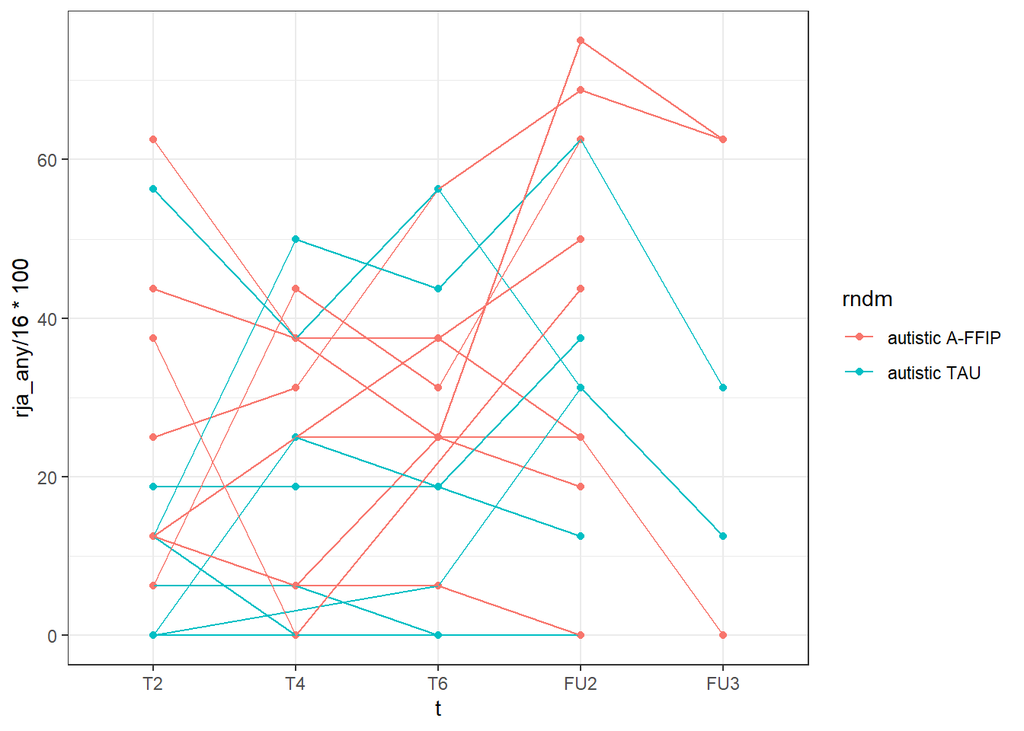

```r
#change to FU
ggplot(df_et_cascades[df_et_cascades$FU_complete==T & df_et_cascades$rndm!='non autistic',],
       aes(x=t,y=rja_any/16*100,color=rndm,group=pic))+geom_point()+geom_line()
```

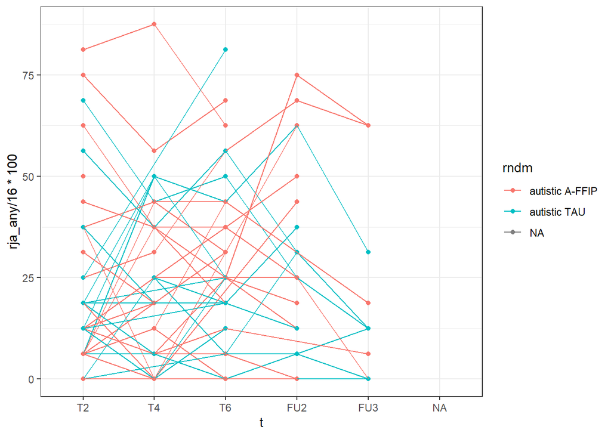

```r
ggplot(df_et_cascades[df_et_cascades$rndm!='non autistic',],
       aes(x=t,y=rja_any/16*100,color=rndm,group=pic))+geom_point()+geom_line()
```

## 9.10 normative model

-create normative model based on non autistic data

```r
glmm<-glmer(rja_any~
                scale(baseline_pd)+
                #condition+position+
                #scale(fixation_duration)+scale(no_data)+
                gender+scale(t_age)+scale(baseline_nonverbal_iq)+
                (1|pic)+(1|index_trial),data=df_trial[df_trial$t %in% c('T2','FU2') &
                                                        df_trial$rndm=='non autistic',],
                                                  family='binomial')

summary(glmm)
```

```
## Generalized linear mixed model fit by maximum likelihood (Laplace
##   Approximation) [glmerMod]
##  Family: binomial  ( logit )
## Formula:
## rja_any ~ scale(baseline_pd) + gender + scale(t_age) + scale(baseline_nonverbal_iq) +
##     (1 | pic) + (1 | index_trial)
##    Data:
## df_trial[df_trial$t %in% c("T2", "FU2") & df_trial$rndm == "non autistic",
##     ]
##
##      AIC      BIC   logLik deviance df.resid
##   1176.4   1210.7   -581.2   1162.4      995
##
## Scaled residuals:
##     Min      1Q  Median      3Q     Max
## -2.9070 -0.6865 -0.1963  0.6872  3.0624
##
## Random effects:
##  Groups      Name        Variance Std.Dev.
##  pic         (Intercept) 1.6959   1.3023
##  index_trial (Intercept) 0.2638   0.5136
## Number of obs: 1002, groups:  pic, 50; index_trial, 16
##
## Fixed effects:
##                              Estimate Std. Error z value Pr(>|z|)
## (Intercept)                   -0.4866     0.3868  -1.258 0.208315
## scale(baseline_pd)            -0.4300     0.1143  -3.763 0.000168 ***
## genderm                        0.6640     0.4754   1.397 0.162489
## scale(t_age)                   0.6738     0.1269   5.310  1.1e-07 ***
## scale(baseline_nonverbal_iq)   0.1238     0.2096   0.590 0.554866
## ---
## Signif. codes:  0 '***' 0.001 '**' 0.01 '*' 0.05 '.' 0.1 ' ' 1
##
## Correlation of Fixed Effects:
##             (Intr) scl(b_) gendrm scl(t_)
## scl(bsln_p)  0.010
## genderm     -0.782 -0.013
## scale(t_ag) -0.123  0.048   0.190
## scl(bsln__) -0.268  0.021   0.401  0.050
```

```r
###--> normative model defined by effects of gender, age at timepoint, baseline PD
r2_nakagawa(glmm)
```

```
## # R2 for Mixed Models
##
##   Conditional R2: 0.440
##      Marginal R2: 0.107
```

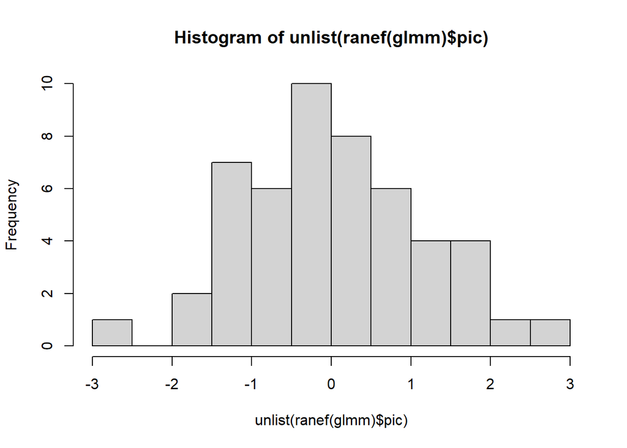

```r
#random effects
hist(unlist(ranef(glmm)$pic),10)
```

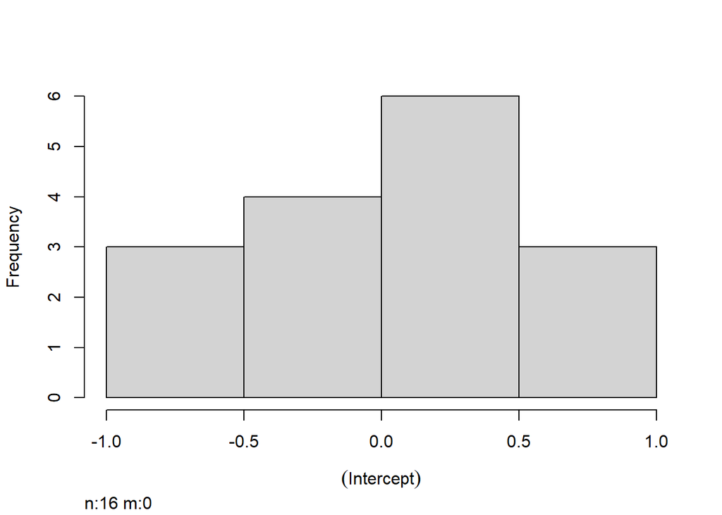

```r
hist(ranef(glmm)$index_trial)
```

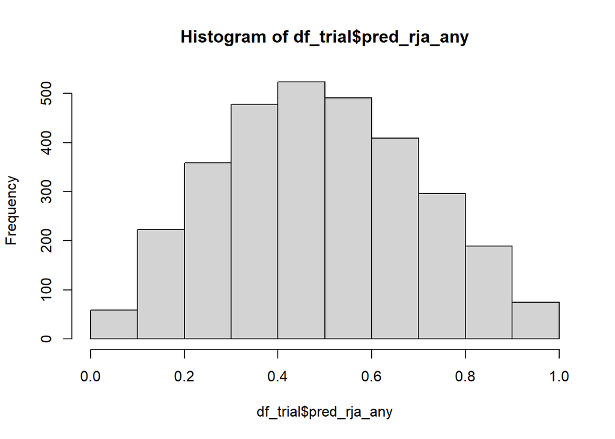

```r
#predicted response as likelihood
df_trial$pred_rja_any<-predict(glmm, df_trial, type = 'response',
                               re.form= ~(1|pic)+(1|index_trial),
                               allow.new.levels=T)

# df_trial$pred_rja_any<-predict(glmm, df_trial, type = 'response',
#                                re.form= NA)

## calculate normative residual score
df_trial$res_rja_any<-with(df_trial,as.numeric(rja_any)-pred_rja_any)

hist(df_trial$pred_rja_any)
```

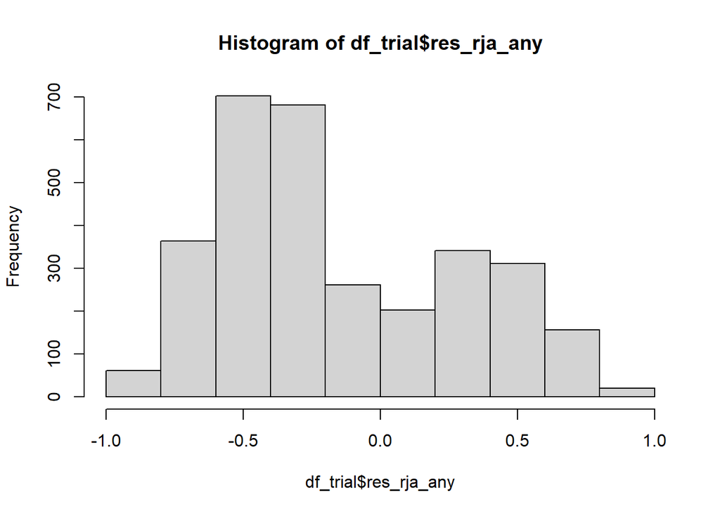

```r
hist(df_trial$res_rja_any)
```

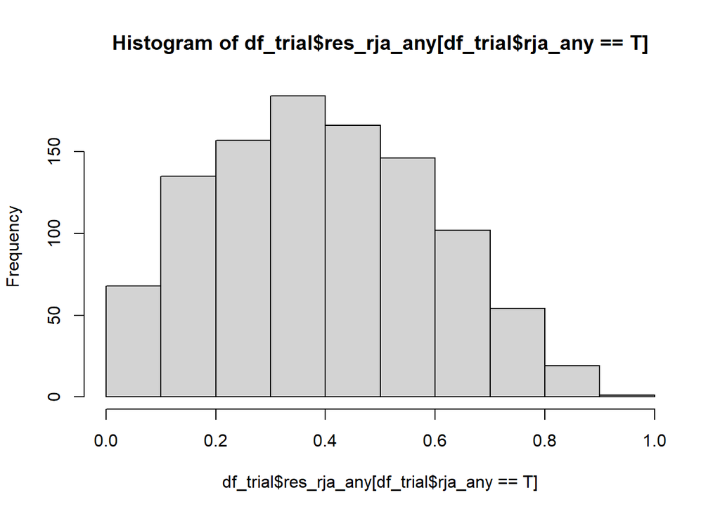

```r
hist(df_trial$res_rja_any[df_trial$rja_any==T])
```

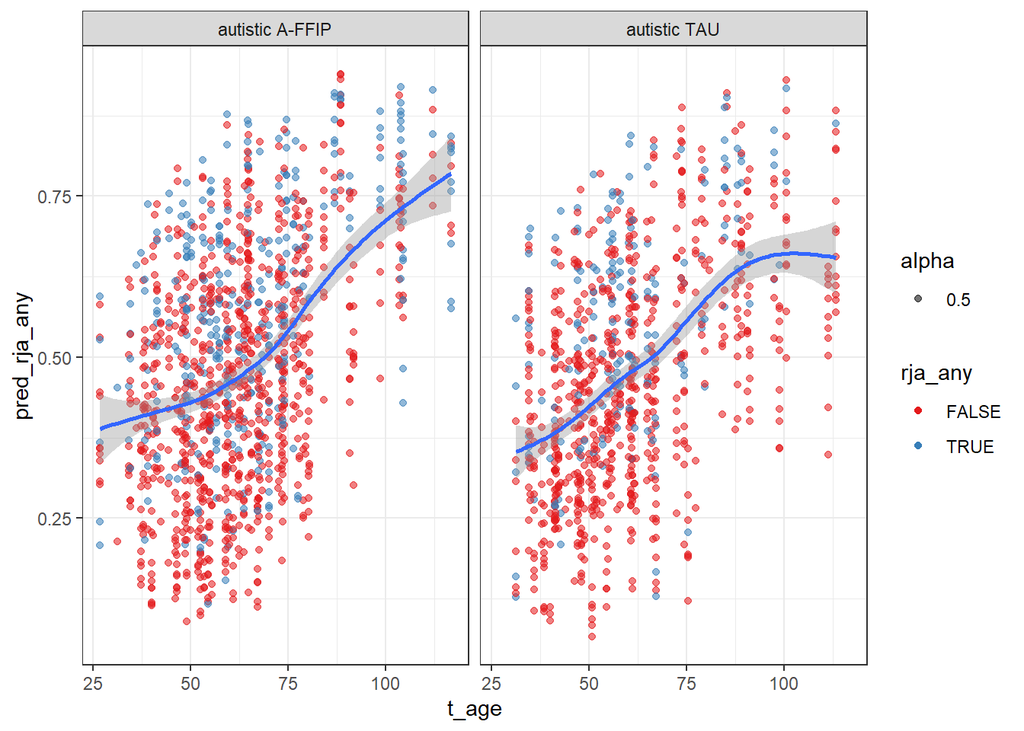

```r
# df_trial$pred_rja_any<-predict(glmm, df_trial, type = 'response',
#                                re.form= NA)

### as a figure
ggplot(df_trial[df_trial$rndm %in% c('autistic A-FFIP','autistic TAU'),],
       aes(x=t_age,y=pred_rja_any))+
  geom_point(aes(color=rja_any,alpha=0.5))+
  geom_smooth()+
  facet_grid(~rndm)+
  scale_color_brewer(palette='Set1')
```

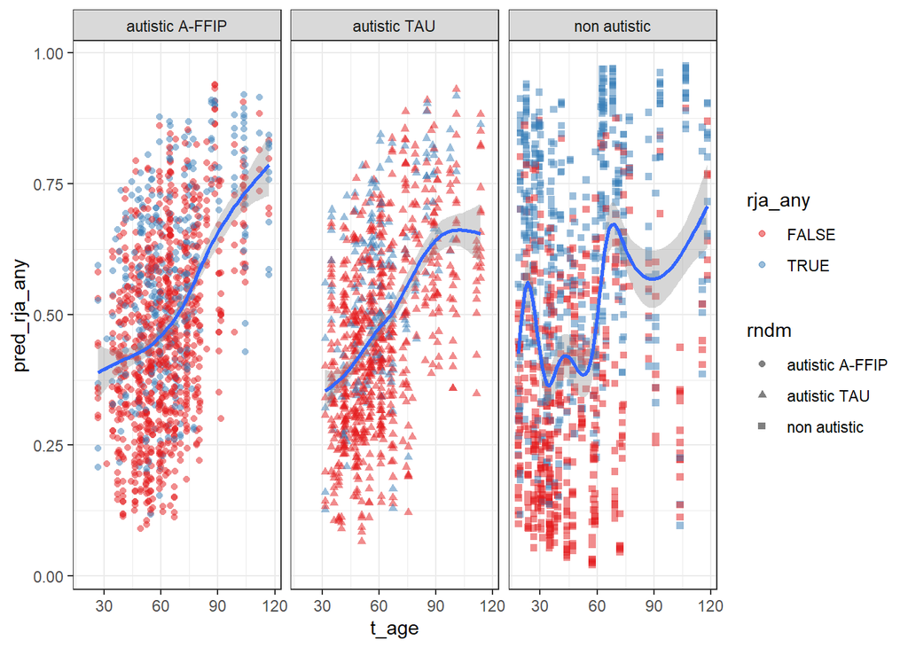

```r
ggplot(df_trial[!is.na(df_trial$rndm),],
       aes(x=t_age,y=pred_rja_any))+
  geom_point(aes(color=rja_any,shape=rndm),alpha=0.5)+
  geom_smooth()+
  facet_grid(~rndm)+
  scale_color_brewer(palette='Set1')
```

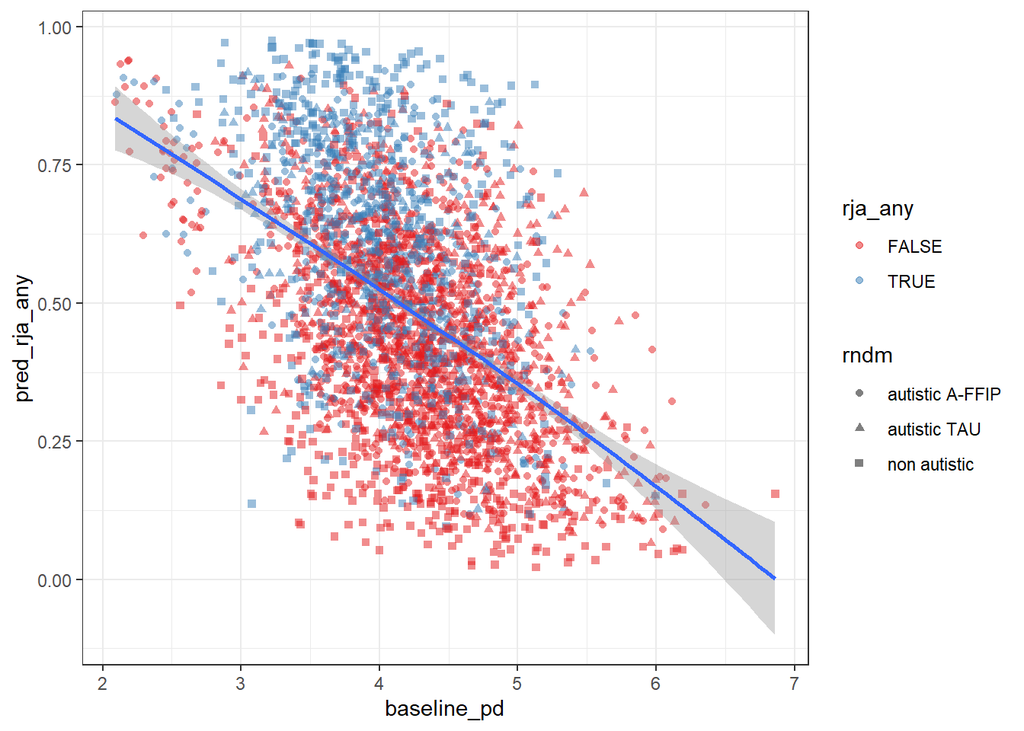

```r
ggplot(df_trial[!is.na(df_trial$rndm),],
       aes(x=baseline_pd,y=pred_rja_any))+
  geom_point(aes(color=rja_any,shape=rndm),alpha=0.5)+
  geom_smooth()+
  scale_color_brewer(palette='Set1')
```

```r
#add to aggregated to evaluate performance

df_pred<-aggregate(df_trial[,names(df_trial)=='pred_rja_any'],
          by=list(df_trial$pic,df_trial$t),
          FUN=mean,na.rm=T)

names(df_pred)<-c('pic','t','pred_rja_any')

df_et_agg<-df_et_agg[,!names(df_et_agg) %in% c('Group.1','Group.2')]

df_et_agg<-merge(df_et_agg,df_pred,by=c('pic','t'),all.x=T)
```

### 9.10.1 test normative model

- in intervention model

```r
lmm<-lmer(res_rja_any~t*rndm+
            (1|pic)+(1|index_trial),data=df_trial[df_trial$t %in% c('T2','T6') &
                                                    df_trial$rndm!='non autistic' &
                                                    df_trial$rja_any==F,])

#model fit
r2_nakagawa(lmm)
```

```
## # R2 for Mixed Models
##
##   Conditional R2: 0.870
##      Marginal R2: 0.081
```

```r
anova(lmm)
```

```
## Type III Analysis of Variance Table with Satterthwaite's method
##         Sum Sq Mean Sq NumDF  DenDF  F value Pr(>F)
## t      1.69888 1.69888     1 823.68 407.8889 <2e-16 ***
## rndm   0.00079 0.00079     1  62.39   0.1886 0.6656
## t:rndm 0.00472 0.00472     1 824.27   1.1341 0.2872
## ---
## Signif. codes:  0 '***' 0.001 '**' 0.01 '*' 0.05 '.' 0.1 ' ' 1
```

```r
fixef(lmm)
```

```
##          (Intercept)                  t.L     rndmautistic TAU
##         -0.435244111         -0.067610788          0.012568363
## t.L:rndmautistic TAU
##         -0.007526561
```

```r
#planned contrasts
contrast(emmeans(lmm,~rndm+t),'pairwise')
```

```
##  contrast                                    estimate      SE    df t.ratio
##  (autistic A-FFIP T2) - autistic TAU T2      -0.01789 0.02922  64.4  -0.612
##  (autistic A-FFIP T2) - (autistic A-FFIP T6)  0.09562 0.00684 825.1  13.973
##  (autistic A-FFIP T2) - autistic TAU T6       0.08837 0.02947  66.6   2.999
##  autistic TAU T2 - (autistic A-FFIP T6)       0.11351 0.02927  64.9   3.877
##  autistic TAU T2 - autistic TAU T6            0.10626 0.00729 822.6  14.575
##  (autistic A-FFIP T6) - autistic TAU T6      -0.00725 0.02953  67.1  -0.245
##  p.value
##   0.9278
##   <.0001
##   0.0195
##   0.0014
##   <.0001
##   0.9948
##
## Degrees-of-freedom method: kenward-roger
## P value adjustment: tukey method for comparing a family of 4 estimates
```

```r
emmeans(lmm,~rndm)
```

```
## NOTE: Results may be misleading due to involvement in interactions
```

```
##  rndm            emmean     SE   df lower.CL upper.CL
##  autistic A-FFIP -0.435 0.0341 30.9   -0.505   -0.366
##  autistic TAU    -0.423 0.0352 34.4   -0.494   -0.351
##
## Results are averaged over the levels of: t
## Degrees-of-freedom method: kenward-roger
## Confidence level used: 0.95
```

```r
contrast(emmeans(lmm,~rndm),'pairwise',adjust='none')
```

```
## NOTE: Results may be misleading due to involvement in interactions
```

```
##  contrast                         estimate     SE df t.ratio p.value
##  (autistic A-FFIP) - autistic TAU  -0.0126 0.0289 62  -0.434  0.6656
##
## Results are averaged over the levels of: t
## Degrees-of-freedom method: kenward-roger
```

```r
confint(contrast(emmeans(lmm,~rndm),'pairwise',adjust='none'))
```

```
## NOTE: Results may be misleading due to involvement in interactions
```

```
##  contrast                         estimate     SE df lower.CL upper.CL
##  (autistic A-FFIP) - autistic TAU  -0.0126 0.0289 62  -0.0704   0.0453
##
## Results are averaged over the levels of: t
## Degrees-of-freedom method: kenward-roger
## Confidence level used: 0.95
```

- in developmental model

```r
#any
lmm<-lmer(res_rja_any~t*rndm+
            (1|pic)+(1|index_trial),data=df_trial[df_trial$t %in% c('T2','FU2') &
                                                    df_trial$rja_any==T,])

#model fit
r2_nakagawa(lmm)
```

```
## # R2 for Mixed Models
##
##   Conditional R2: 0.927
##      Marginal R2: 0.149
```

```r
anova(lmm)
```

```
## Type III Analysis of Variance Table with Satterthwaite's method
##         Sum Sq Mean Sq NumDF  DenDF  F value    Pr(>F)
## t      1.84163 1.84163     1 648.70 463.7831 < 2.2e-16 ***
## rndm   0.00087 0.00043     2  99.28   0.1092    0.8967
## t:rndm 0.10089 0.05045     2 644.99  12.7043 3.877e-06 ***
## ---
## Signif. codes:  0 '***' 0.001 '**' 0.01 '*' 0.05 '.' 0.1 ' ' 1
```

```r
#planned contrasts
confint(contrast(emmeans(lmm,~t|rndm),'revpairwise'))
```

```
## rndm = autistic A-FFIP:
##  contrast estimate      SE  df lower.CL upper.CL
##  FU2 - T2   -0.241 0.01561 638   -0.272   -0.210
##
## rndm = autistic TAU:
##  contrast estimate      SE  df lower.CL upper.CL
##  FU2 - T2   -0.208 0.02204 656   -0.251   -0.165
##
## rndm = non autistic:
##  contrast estimate      SE  df lower.CL upper.CL
##  FU2 - T2   -0.157 0.00795 625   -0.172   -0.141
##
## Degrees-of-freedom method: kenward-roger
## Confidence level used: 0.95
```

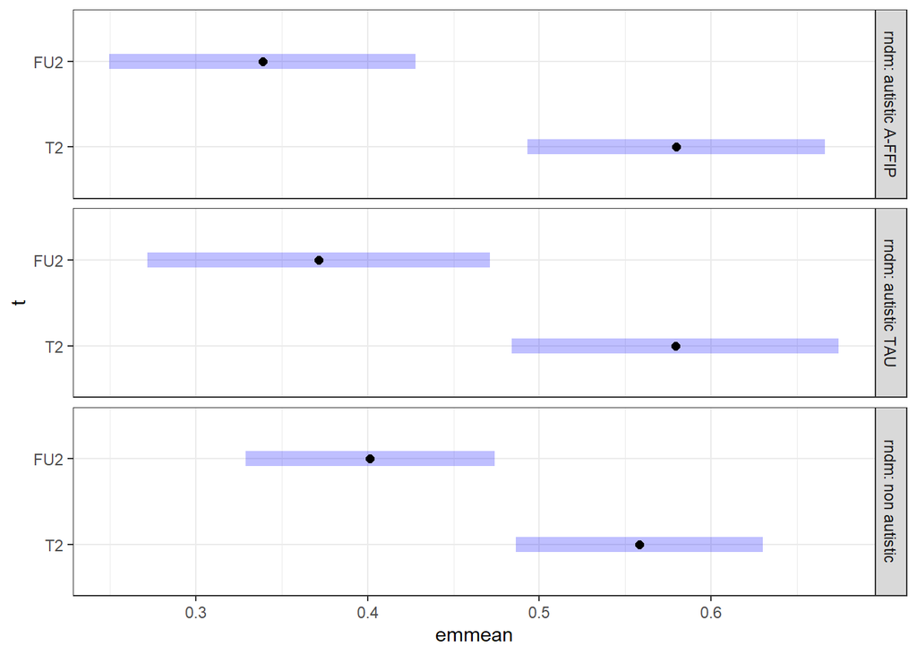

```r
plot(emmeans(lmm,~t|rndm))
```

```r
contrast(emmeans(lmm,~t|rndm),'revpairwise')
```

```
## rndm = autistic A-FFIP:
##  contrast estimate      SE  df t.ratio p.value
##  FU2 - T2   -0.241 0.01561 638 -15.430  <.0001
##
## rndm = autistic TAU:
##  contrast estimate      SE  df t.ratio p.value
##  FU2 - T2   -0.208 0.02204 656  -9.429  <.0001
##
## rndm = non autistic:
##  contrast estimate      SE  df t.ratio p.value
##  FU2 - T2   -0.157 0.00795 625 -19.733  <.0001
##
## Degrees-of-freedom method: kenward-roger
```

```r
# comparsion at timepoints
confint(contrast(emmeans(lmm,~rndm|t),'pairwise'))
```

```
## t = T2:
##  contrast                         estimate     SE    df lower.CL upper.CL
##  (autistic A-FFIP) - autistic TAU   0.0005 0.0544 100.8  -0.1289   0.1299
##  (autistic A-FFIP) - non autistic   0.0216 0.0443  97.4  -0.0838   0.1269
##  autistic TAU - non autistic        0.0211 0.0485 100.0  -0.0944   0.1365
##
## t = FU2:
##  contrast                         estimate     SE    df lower.CL upper.CL
##  (autistic A-FFIP) - autistic TAU  -0.0326 0.0577 124.9  -0.1694   0.1042
##  (autistic A-FFIP) - non autistic  -0.0626 0.0458 110.7  -0.1714   0.0463
##  autistic TAU - non autistic       -0.0300 0.0512 121.5  -0.1514   0.0914
##
## Degrees-of-freedom method: kenward-roger
## Confidence level used: 0.95
## Conf-level adjustment: tukey method for comparing a family of 3 estimates
```

```r
contrast(emmeans(lmm,~rndm|t),'pairwise')
```

```
## t = T2:
##  contrast                         estimate     SE    df t.ratio p.value
##  (autistic A-FFIP) - autistic TAU   0.0005 0.0544 100.8   0.009  1.0000
##  (autistic A-FFIP) - non autistic   0.0216 0.0443  97.4   0.487  0.8777
##  autistic TAU - non autistic        0.0211 0.0485 100.0   0.434  0.9016
##
## t = FU2:
##  contrast                         estimate     SE    df t.ratio p.value
##  (autistic A-FFIP) - autistic TAU  -0.0326 0.0577 124.9  -0.565  0.8390
##  (autistic A-FFIP) - non autistic  -0.0626 0.0458 110.7  -1.365  0.3625
##  autistic TAU - non autistic       -0.0300 0.0512 121.5  -0.586  0.8279
##
## Degrees-of-freedom method: kenward-roger
## P value adjustment: tukey method for comparing a family of 3 estimates
```

# 10 figures

## 10.1 figure - material and measures

### 10.1.1 figure prepare data set

```r
#prepare data set
df_jointatt_plot<-df_jointatt[df_jointatt$t %in% c('T2','T6','FU2'),]
levels(df_jointatt_plot$t)<-c('baseline','T4','end-of-treatent','follow-up','FU3')

#define joint attention phases
df_jointatt_plot$phase<-as.factor(with(df_jointatt_plot,dplyr::case_when(
  ts_event>300 &  ts_event<=1050 ~ 'intro direct gaze',
  ts_event>1050 &  ts_event<=2850 ~ 'target cueing',
  ts_event>2850 ~ 'outro direct gaze',
  )))

df_jointatt_plot$phase<-
  ordered(df_jointatt_plot$phase, levels = c("intro direct gaze",
                                             "target cueing",
                                             "outro direct gaze"))

#target position as factor
df_jointatt_plot$position<-as.factor(df_jointatt_plot$position)
levels(df_jointatt_plot$position)<-c('target left','target right')
```

### 10.1.2 figure panel - RJA likelihood

```r
##RJA between timepoints and groups: density = count / n

# g_rja<-ggplot(df_jointatt_plot,
#        aes(x=rja_when/300,
#            group=t,fill=rndm))+
#   geom_density(adjust=1.5,trim=T)+
#   labs(x='trial duration (s)',y='')+
#   xlim(c(0,11))+
#   geom_vline(xintercept=1)+geom_vline(xintercept=3.5,linetype='dashed')+
#   geom_vline(xintercept=9.5,linetype='dashed')+
#   scale_fill_brewer(palette='Dark2')+
#   #facet_grid(rndm~t,scales = 'free_y')+theme_bw()
#   labs(fill='group',title = 'C.) RJA occurances (density)')+ #custom labels
#   facet_grid(t~rndm)+theme_bw()+
#   theme(legend.position = 'none')


 df_jointatt_plot$group_asd<-ifelse(df_jointatt_plot$rndm!='non autistic','autistic','non autistic')
 g_rja<-ggplot(df_jointatt_plot,
       aes(x=rja_when/300,fill=rndm))+
  geom_density(adjust=2,trim=T,alpha=.7)+
  labs(x='trial duration (s)',y='')+
  xlim(c(0,11))+
  geom_vline(xintercept=1)+geom_vline(xintercept=3.5,linetype='dashed')+
  geom_vline(xintercept=9.5,linetype='dashed')+
  scale_fill_brewer(palette='Dark2')+
  #facet_grid(rndm~t,scales = 'free_y')+theme_bw()
  labs(fill='group',title = 'C.) RJA likelihood within trials (density)')+ #custom labels
  facet_grid(t~group_asd)+theme_bw()+
  theme(legend.position = 'none')
```

### 10.1.3 figure panel - pupillometry

```r
##define percentage of data sampling for visualization
subsample<-sample(1:nrow(df_jointatt_plot),nrow(df_jointatt_plot)/sampling_factor)
#--> select 10% of data for faster plotting (faster rendering)

#adapt data set for plotting
df_jointatt_plot_pupil<-df_jointatt_plot[subsample,]

# #pupil size progression - between conditions
# #--> between timepoints x groups
# g_pupil<-ggplot(df_jointatt_plot_pupil,
#        aes(x=ts_event/300,y=rpd,group=rndm,color=rndm))+
#   geom_smooth(aes(fill=rndm))+theme_bw()+
#   labs(title='D.) pupil size change (mm)',
#        x='trial duration (s)',
#        y='')+
#   geom_vline(xintercept=1)+geom_vline(xintercept=3.5,linetype='dashed')+ #mark video segments
#   geom_vline(xintercept=9.5,linetype='dashed')+ #mark video segments
#   scale_fill_brewer(palette='Dark2')+ #custom color
#   scale_color_brewer(palette='Dark2')+ #custom color
#   labs(color='group',fill='group')+ #custom labels
#   facet_grid(t~.)+
#   theme(legend.position = 'none')


#pupil size progression within complete trial across groups
g_pupil<-ggplot(df_jointatt_plot_pupil,
       aes(x=ts_event/300,y=pd))+
  geom_smooth(color='black',fill='darkgrey')+
  labs(title='D.) pupil size change within trials',
       x='trial duration (s)',
       y='pupil size (mm)')+
  geom_vline(xintercept=1)+geom_vline(xintercept=3.5,linetype='dashed')+ #mark video segments
  geom_vline(xintercept=9.5,linetype='dashed')+ #mark video segments
  #remove y axis title as later combioned to grob
  theme(axis.title.y=element_blank())



#baseline pupil size
#select only attention grabber phase
df_jointatt_plot_bps<-df_jointatt_plot[df_jointatt_plot$time_s<=1,]
g_bps<-ggplot(df_jointatt_plot_bps,aes(x=ts_event/300,y=pd))+
  geom_smooth(color='black',fill='darkgrey')+
  geom_vline(linetype=2,xintercept=c(0,0.5))+
  annotate("rect", xmin = 0, xmax = 0.5, ymin = 4, ymax = 4.25, alpha = .2)+
  labs(x='time in trial (s)',y='pupil size (mm)',title='E.) BPS: baseline size')+
  #remove y axis title as later combioned to grob
  theme(axis.title.y=element_blank())

#stimulus-evoked pupillary response
#select only gaze cued associated response
df_jointatt_plot_sepr<-df_jointatt_plot[df_jointatt_plot$time_s>=4 & df_jointatt_plot$time_s<=6,]
g_sepr<-ggplot(df_jointatt_plot_sepr,aes(x=ts_event/300,y=pd))+
  geom_smooth(color='black',fill='darkgrey')+
  geom_vline(linetype=2,xintercept=c(4.5,5.5))+
  annotate("rect", xmin = 4.5, xmax = 5.5, ymin = 4.15, ymax = 4.225, alpha = .2)+
  labs(x='time in trial (s)',y='pupil size (mm)',title='F.) SEPR: evoked response')+
  #remove y axis title as later combioned to grob
  theme(axis.title.y=element_blank())
```

### 10.1.4 figure panel - heatmaps

```r
#define color
custom_palette<-brewer.pal(8,'Reds')[c(1,4,8)]

##define percentage of data sampling for visualization
subsample<-sample(1:nrow(df_jointatt_plot),nrow(df_jointatt_plot)/sampling_factor)
#--> select 10% of data for faster plotting (faster rendering)

df_jointatt_plot_heatmap<-df_jointatt_plot[subsample,]
df_jointatt_plot_heatmap<-df_jointatt_plot_heatmap[!is.na(df_jointatt_plot_heatmap$phase),]

##gaze locations across video
g_gaze<-ggplot(df_jointatt_plot_heatmap,aes(x=gazepos_x,y=gazepos_y))+
  #geom_hex(bins=100)+
  stat_density_2d(aes(fill=after_stat(density)), n=100, geom = "raster", contour = FALSE)+
  #scale_fill_gradientn(colours=custom_palette)+
  scale_fill_gradientn(colours = c("red","red","orangered","orange","gold","yellow","green3","deepskyblue3",'white'),
                       values = c(1.0,0.5,0.2,0.15,0.1,0.07,0.05,0.02,0))+
  ylim(1,0)+xlim(0,1)+coord_fixed(ratio = 9/16)+
  labs(x='',y='',title='B.) gaze heatmap')+
  theme_classic()+
  facet_grid(position~phase)+
  theme(legend.position = 'none',
        axis.text = element_blank(),
        axis.ticks = element_blank(),
        axis.title = element_blank(),
        panel.spacing = unit(.05, "lines"), #borders around every panel
        panel.border = element_rect(color = "black", fill = NA, size = 1),#borders
        strip.background = element_rect(color = "black", size = 1)) #borders around every panel
```

### 10.1.5 figure panel - stimulus material

loads image from file

```r
#read image - stimulus
require(magick)
img_data<-image_read(paste0(project_path,"/output/figure_material_stimulus.png"))
g_image<-image_ggplot(img_data)+labs(title='A.) trial phases')+
     annotate(geom = 'text',x=260,y=650,
              label='intro direct gaze',size=3,color='white')+
     annotate(geom = 'text',x=1550,y=650,
              label='target cueing',size=3,color='white')+
     annotate(geom = 'text',x=2930,y=650,
              label='outro direct gaze',size=3,color='white')
```

### 10.1.6 figure composite

```r
#extract legend function
g_legend<-function(x){
  tmp <- ggplot_gtable(ggplot_build(x))
  leg <- which(sapply(tmp$grobs, function(x) x$name) == "guide-box")
  legend <- tmp$grobs[[leg]]
  return(legend)}

#temp plot
g1<-ggplot(df_jointatt_plot,
       aes(x=rja_when/300,
           group=t,fill=rndm))+
  geom_density(adjust=1.5,trim=T)+
  scale_fill_brewer(palette='Dark2')+
  labs(fill='group')+ #custom labels
  facet_grid(t~rndm)+theme_bw()+
  theme(legend.position = 'bottom')

#--> extract legend
mylegend<-g_legend(g1)
###--> plot figure

###--> print to file
#define size and resolution of the resulting figure
tiff(file=paste0(project_path,"/output/figures/figure_stimulus_material_revised.tiff"),
     width=9, height=13, units="in", res=600, compression='lzw')

# #plot to file
# grid.arrange(g_image,g_gaze,g_rja,g_pupil,mylegend,
#              widths= c(1,2,2), # composite 3 and 4 in relation of 3:2
#              heights = c(2,2,2,4,2,1),
#              layout_matrix = rbind(c(1,1,1),
#                                    c(2,2,2),
#                                    c(2,2,2),
#                                    c(3,3,4),
#                                    c(3,3,4),
#                                    c(5,5,5)))

#plot to file
grob_pupil<-arrangeGrob(g_pupil,g_bps,g_sepr,ncol=1,left='pupil size (mm)')
grid.arrange(g_image,g_gaze,g_rja,grob_pupil,mylegend,
             widths= c(1,2,2), # composite 3 and 4 in relation of 3:2
             heights = c(2,2,2,3,3,3,1),
             layout_matrix = rbind(c(1,1,1),
                                   c(2,2,2),
                                   c(2,2,2),
                                   c(3,3,4),
                                   c(3,3,4),
                                   c(3,3,4),
                                   c(5,5,5)))
#close operation and save file
dev.off()
```

## 10.2 figure - RJA, BPS, SEPR between timepoints

### 10.2.1 violin plot panel

```r
#create data set aggregated by participant for RJA
df_trial_plot<-df_trial[df_trial$t %in% c('T2','T6','FU2') & !is.na(df_trial$rndm),]
rja_any_sum<-as.numeric(with(df_trial_plot,
                             by(rja_any,droplevels(interaction(rndm,t,id)),sum)))
rja_n<-as.numeric(with(df_trial_plot,
                             by(rja_any,droplevels(interaction(rndm,t,id)),length)))
bps_n<-as.numeric(with(df_trial_plot,
                             by(baseline_pd,
                                droplevels(interaction(rndm,t,id)),mean,na.rm=T)))
sepr_n<-as.numeric(with(df_trial_plot,
                             by(rpd_middle,
                                droplevels(interaction(rndm,t,id)),mean,na.rm=T)))
rndm<-as.factor(with(df_trial_plot,
                             by(rndm,droplevels(interaction(rndm,t,id)),head,n=1)))
levels(rndm)<-levels(df_trial$rndm)
t<-as.factor(with(df_trial_plot,
                             by(t,droplevels(interaction(rndm,t,id)),head,n=1)))
levels(t)<-c('baseline','end-of-treatment','follow-up')
id<-as.factor(with(df_trial_plot,
                             by(id,droplevels(interaction(rndm,t,id)),head,n=1)))

df_trial_plot_rja<-data.frame(rja_any_sum,bps_n,sepr_n,rja_n,rndm,t,id)

#plot RJA
g_rja<-ggplot(df_trial_plot_rja,aes(x=rndm,y=rja_any_sum/rja_n*100,fill=rndm))+
  geom_violin(width=1,trim=T) +
  geom_boxplot(width=0.2, color="grey", alpha=0.2)+
  scale_fill_brewer(palette='Dark2')+
  labs(x='group',y='RJA likelihood (%)',fill='group')+
  theme(axis.text.x = element_blank())+
  facet_grid(.~t)


#plot BPS
g_bps<-ggplot(df_trial_plot_rja,aes(x=rndm,y=bps_n,fill=rndm))+
  geom_violin(width=1,trim=T) +
  geom_boxplot(width=0.2, color="grey", alpha=0.2)+
  scale_fill_brewer(palette='Dark2')+
  labs(x='group',y='BPS (mm) \n',fill='group')+
  theme(axis.text.x = element_blank())+
  facet_grid(.~t)

#plot SEPR
g_sepr<-ggplot(df_trial_plot_rja,aes(x=rndm,y=sepr_n,fill=rndm))+
  geom_violin(width=1,trim=T) +
  geom_boxplot(width=0.2, color="grey", alpha=0.2)+
  scale_fill_brewer(palette='Dark2')+
  labs(x='group',y='SEPR (mm)',fill='group')+
  theme(axis.text.x = element_blank())+
  facet_grid(.~t)

#extract legend
#extract legend function
g_legend<-function(x){
  tmp <- ggplot_gtable(ggplot_build(x))
  leg <- which(sapply(tmp$grobs, function(x) x$name) == "guide-box")
  legend <- tmp$grobs[[leg]]
  return(legend)}

#temp plot
g1<-ggplot(df_trial_plot_rja,aes(x=rndm,y=rja_any_sum/rja_n*100,fill=rndm))+
  geom_violin(width=1,trim=T) +
  geom_boxplot(width=0.2, color="grey", alpha=0.2)+
  labs(fill='group')+
  scale_fill_brewer(palette='Dark2')+
  theme(legend.position = 'bottom')

#--> extract legend
mylegend<-g_legend(g1)
```

### 10.2.2 panel scatterplot

```r
### figure panel association with RJA

df_plot<-df_et_agg[df_et_agg$t %in% c('T2','T6','FU2') & !is.na(df_et_agg$rndm),]

g_age_rja<-ggplot(df_plot,aes(x=t_age,y=rja_any/16*100,color=rndm,fill=rndm))+
  geom_point(aes(shape=t))+
  geom_smooth(method='lm')+
  scale_color_brewer(palette='Dark2')+
  scale_fill_brewer(palette='Dark2')+
  ylim(c(0,100))+
  labs(x='age (months)',y='RJA likelihood (%)')+
  theme(legend.position = 'none')+
  facet_grid(~rndm)

g_bps_rja<-ggplot(df_plot,aes(x=baseline_pd,y=rja_any/16*100,color=rndm,fill=rndm))+
  geom_point(aes(shape=t))+
  geom_smooth(method='lm')+
  scale_color_brewer(palette='Dark2')+
  scale_fill_brewer(palette='Dark2')+
  #xlim(c(3,6))+
  ylim(c(0,100))+
  labs(x='BPS (mm)',y='RJA likelihood (%)')+
  theme(legend.position = 'none')+
  facet_grid(~rndm)

g_sepr_rja<-ggplot(df_plot,aes(x=rpd_middle,y=rja_any/16*100,color=rndm,fill=rndm))+
  geom_point(aes(shape=t))+
  geom_smooth(method='lm')+
  scale_color_brewer(palette='Dark2')+
  scale_fill_brewer(palette='Dark2')+
  #xlim(c(-0.5,0.5))+
  ylim(c(0,100))+
  labs(x='SEPR (mm)',y='RJA likelihood (%)')+
  theme(legend.position = 'none')+
  facet_grid(~rndm)

#temp plot
g1<-ggplot(df_plot,aes(x=t_age,y=rja_any))+
  geom_point(aes(shape=t))+
  labs(shape='timepoint')+
  scale_shape_manual(labels=c("baseline","end-of-treatment","follow-up"),
                     values=c(16,17,15))+
  theme(legend.position = 'bottom')

#--> extract legend
mylegend2<-g_legend(g1)
```

### 10.2.3 print figure

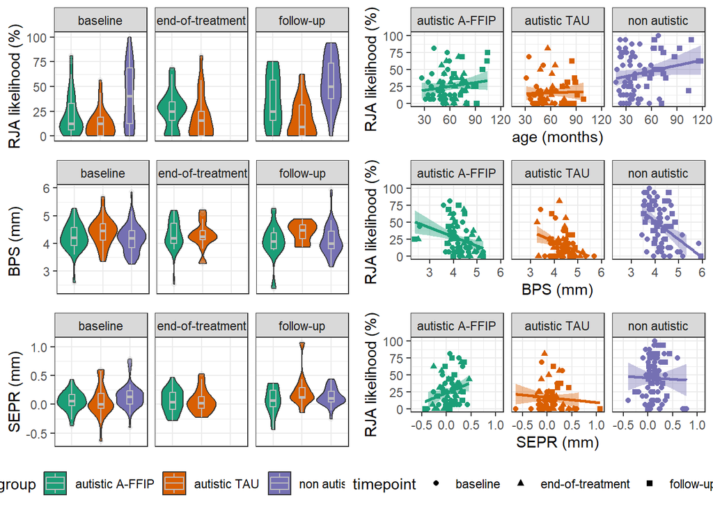

```r
grid.arrange(g_rja+
               theme(legend.position = 'none',
                     axis.title.x = element_blank(),
                     axis.ticks.x = element_blank()),

             g_age_rja,

             g_bps+
               theme(legend.position = 'none',
                     axis.title.x = element_blank(),
                     axis.ticks.x = element_blank()),

             g_bps_rja,

             g_sepr+
               theme(legend.position = 'none',
                     axis.title.x = element_blank(),
                     axis.ticks.x = element_blank()),

             g_sepr_rja,

             mylegend,

             mylegend2,

             ncol=2,
             heights=c(3,3,3,1))
```

```r
###--> print to file
#define size and resolution of the resulting figure
tiff(file=paste0(project_path,"/output/figures/figure_measures_by_group2.tiff"),
     width=10, height=6, units="in", res=600, compression='lzw')

# grid.arrange(g_rja+
#                theme(legend.position = 'none',
#                      axis.title.x = element_blank(),
#                      axis.ticks.x = element_blank()),
#              g_bps+
#                theme(legend.position = 'none',
#                      axis.title.x = element_blank(),
#                      axis.ticks.x = element_blank()),
#              g_sepr+
#                theme(legend.position = 'none',
#                      axis.title.x = element_blank(),
#                      axis.ticks.x = element_blank()),
#              mylegend,
#              ncol=1,
#              heights=c(3,3,3,1))

grid.arrange(g_rja+
               theme(legend.position = 'none',
                     axis.title.x = element_blank(),
                     axis.ticks.x = element_blank()),

             g_age_rja,

             g_bps+
               theme(legend.position = 'none',
                     axis.title.x = element_blank(),
                     axis.ticks.x = element_blank()),

             g_bps_rja,

             g_sepr+
               theme(legend.position = 'none',
                     axis.title.x = element_blank(),
                     axis.ticks.x = element_blank()),

             g_sepr_rja,

             mylegend,

             mylegend2,

             ncol=2,
             heights=c(3,3,3,1))
#close operation and save file
dev.off()
```

## 10.3 figure - developmental cascade

figure caption: Cascade effects - Assocation of changes in RJA likelihood and BPS from baseline (BL) to end-of-treatment (ET) on socio cognitive development. Socio-cognitive development is measured by changes from baseline (BL) to follow-up (FU) in social responsiveness (SRS-16 total score), repetitive behavior (RBSR total score), and nonverbal IQ change (Bayley III or WPPSI).

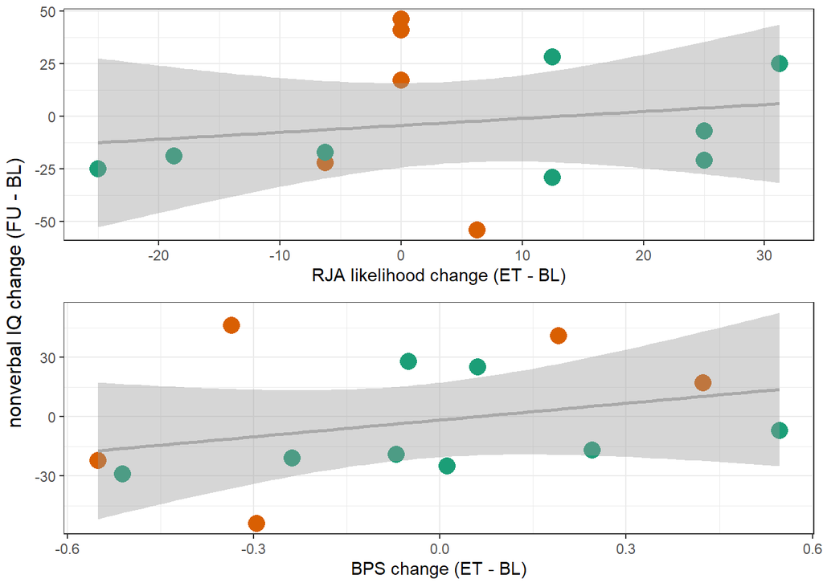

```r
#extract legend function
g_legend<-function(x){
  tmp <- ggplot_gtable(ggplot_build(x))
  leg <- which(sapply(tmp$grobs, function(x) x$name) == "guide-box")
  legend <- tmp$grobs[[leg]]
  return(legend)}

#temp plot
g1<-ggplot(df_cascades[df_cascades$rndm!='non autistic',],
       aes(rja_any_diff_t2t6/16*100,nonverbal_iq_diff_t2fu))+geom_point(aes(color=rndm))+
  geom_smooth(color='darkgrey',method='lm',show.legend = F)+
  scale_color_brewer(palette='Dark2')+
  labs(color='group')

#--> extract legend
mylegend<-g_legend(g1)
g1<-ggplot(df_cascades[df_cascades$rndm!='non autistic',],
       aes(rja_any_diff_t2t6/16*100,nonverbal_iq_diff_t2fu))+
  geom_point(aes(size=2,color=rndm))+
  geom_smooth(color='darkgrey',method='lm',show.legend = F)+
  xlab('RJA likelihood change (ET - BL)')+
  scale_color_brewer(palette='Dark2')+
  theme(legend.position = 'none',axis.title.y=element_blank())

g2<-ggplot(df_cascades[df_cascades$rndm!='non autistic',],
       aes(baseline_pd_diff_t2t6,nonverbal_iq_diff_t2fu))+
  geom_point(aes(size=2,color=rndm))+
  geom_smooth(color='darkgrey',method='lm',show.legend = F)+
  xlab('BPS change (ET - BL)')+
  #annotate(geom="text", x=0, y=30, label="n.s.", color='blue')+
  scale_color_brewer(palette='Dark2')+
  theme(legend.position = 'none',axis.title.y=element_blank())

g3<-ggplot(df_cascades[df_cascades$rndm!='non autistic',],
       aes(rja_any_diff_t2t6/16*100,srs16_sum_diff_t2fu))+
  geom_point(aes(size=2,color=rndm))+
  geom_smooth(color='darkgrey',method='lm',show.legend = F)+
  xlab('RJA likelihood change (ET - BL)')+
  annotate(geom="text", x=0, y=20, label="-1.01*", color='black')+
  scale_color_brewer(palette='Dark2')+
  theme(legend.position = 'none',axis.title.y=element_blank())

g4<-ggplot(df_cascades[df_cascades$rndm!='non autistic',],
       aes(baseline_pd_diff_t2t6,srs16_sum_diff_t2fu))+
  geom_point(aes(size=2,color=rndm))+
  geom_smooth(color='darkgrey',method='lm',show.legend = F)+
  xlab('BPS change (ET - BL)')+
  annotate(geom="text", x=0, y=20, label="-0.79'", color='black')+
  scale_color_brewer(palette='Dark2')+
  theme(legend.position = 'none',axis.title.y=element_blank())

g5<-ggplot(df_cascades[df_cascades$rndm!='non autistic',],
       aes(rja_any_diff_t2t6/16*100,RBSR_ges_diff_t2fu))+
  geom_point(aes(size=2,color=rndm))+
  geom_smooth(color='darkgrey',method='lm',show.legend = F)+
  xlab('RJA likelihood change (ET - BL)')+
  annotate(geom="text", x=0, y=25, label="-0.60'", color='black')+
  scale_color_brewer(palette='Dark2')+
  theme(legend.position = 'none',axis.title.y=element_blank())

g6<-ggplot(df_cascades[df_cascades$rndm!='non autistic',],
       aes(baseline_pd_diff_t2t6,RBSR_ges_diff_t2fu))+
  geom_point(aes(size=2,color=rndm))+
  geom_smooth(color='darkgrey',method='lm',show.legend = F)+
  xlab('BPS change (ET - BL)')+
  annotate(geom="text", x=0, y=20, label="", color='blue')+
  scale_color_brewer(palette='Dark2')+
  theme(legend.position = 'none',axis.title.y=element_blank())

g12<-grid.arrange(g1,g2,left='nonverbal IQ change (FU - BL)')
```

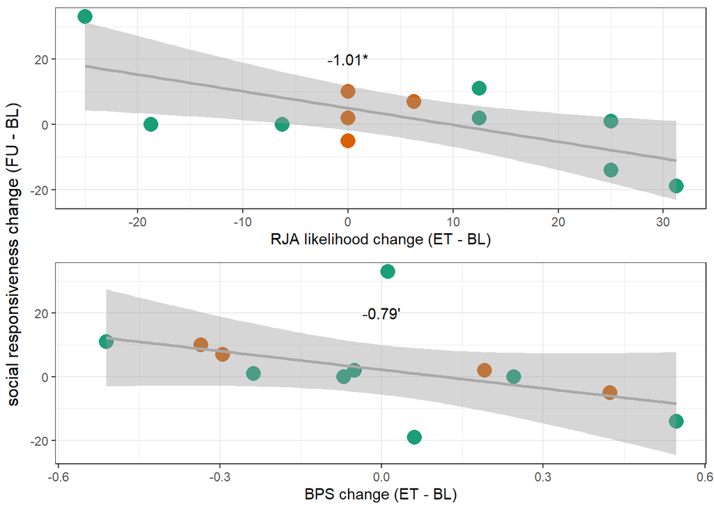

```r
g34<-grid.arrange(g3,g4,left='social responsiveness change (FU - BL)')
```

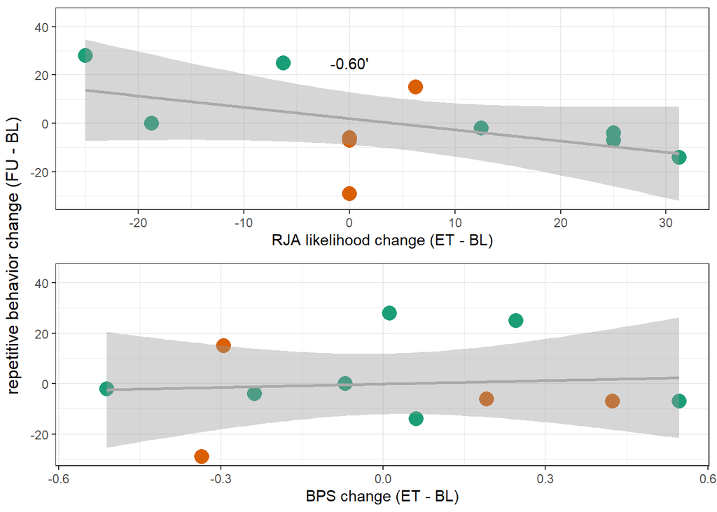

```r
g56<-grid.arrange(g5,g6,left='repetitive behavior change (FU - BL)')
```

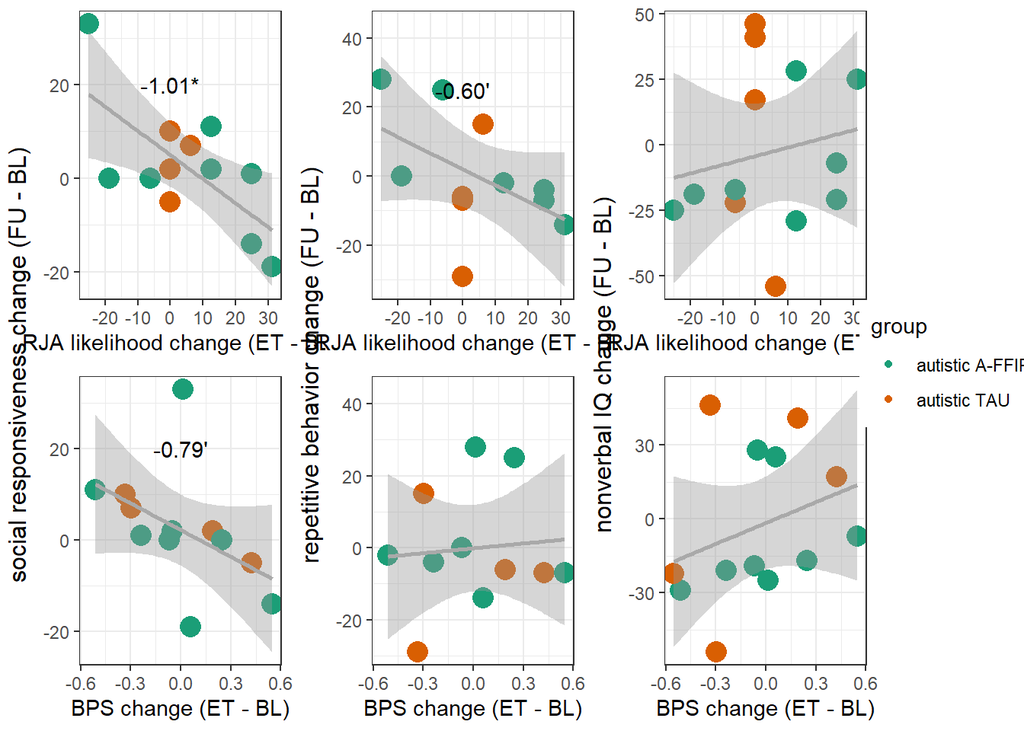

```r
#plot in markdown
grid.arrange(g34,g56,g12,mylegend,ncol=4,widths=c(2,2,2,1))
```

```r
##save to file
# create a file in tiff format in current working directory
#define size and resolution of the resulting figure
tiff(file=paste0(project_path,"/output/figures/figure_cascades.tiff"),
     width=10, height=5, units="in", res=300, compression='lzw')

#plot to file
grid.arrange(g34,g56,g12,mylegend,ncol=4,widths=c(2,2,2,1))

#close operation and save file
dev.off()
```

# 11 supplements

## 11.1 supplement - figure distributions

- per sample data figure

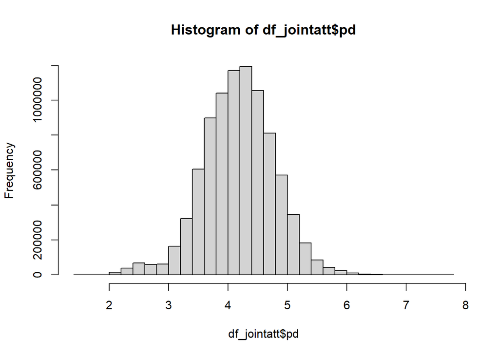

```r
hist(df_jointatt$pd)
```

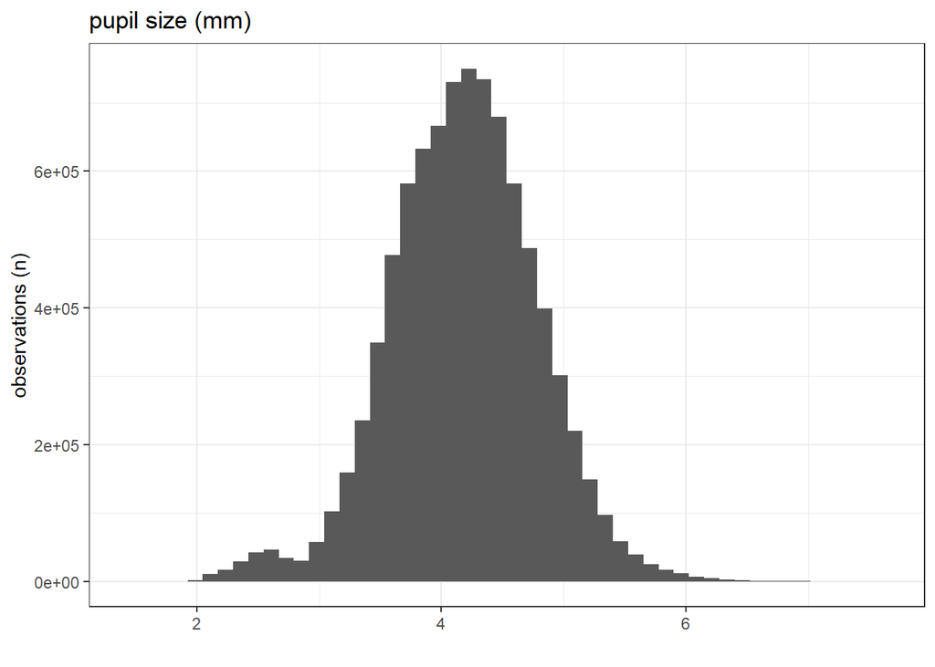

```r
ggplot(df_jointatt,aes(x=pd))+geom_histogram(bins=50)+
  labs(x='',y='observations (n)',title='pupil size (mm)')
```

## 11.2 supplement - random effect distribution

```r
##in intervention model
glmm<-glmer(rja_any~t*rndm+
            (1|pic)+(1|index_trial),data=df_trial[df_trial$t %in% c('T2','T6') &
                                                    df_trial$rndm!='non autistic',],family='binomial')

#random effect distribution
df_plot<-data.frame(scale(ranef(glmm)$pic))
g_re1<-ggplot(df_plot,aes(x=X.Intercept.))+geom_histogram(color='grey',bins=20)+
  labs(x='Intervention model: Heterogeneity in RJA (participant random intercept, z)')


#development model
glmm<-glmer(rja_any~t*rndm+
            (1|pic)+(1|index_trial),data=df_trial[df_trial$t %in% c('T2','FU2'),],family='binomial')

#random effect distribution
df_plot<-data.frame(scale(ranef(glmm)$pic))
g_re2<-ggplot(df_plot,aes(x=X.Intercept.))+geom_histogram(color='grey',bins=20)+
  labs(x='Development model: Heterogeneity in RJA (participant random intercept, z)')

#define size and resolution of the resulting figure
tiff(file=paste0(project_path,"/output/supplements/figure_particiopant_random_effect.tiff"),
     width=6, height=8, units="in", res=600, compression='lzw')

grid.arrange(g_re1,g_re2)

dev.off()
```

## 11.3 supplement - date of assessment

```r
table(demogr$t)
```

```
##
##  T1  T2  T3  T4  T5  T6  FU FU2 FU3
## 133 133 133 133 133 133 133 131 133
```

```r
demogr_sup<-demogr[demogr$t %in% c('T2','T6','FU2'),]
demogr_sup$timepoint<-droplevels(as.factor(demogr_sup$t))
levels(demogr_sup$timepoint)<-c('baseline','end-of-treatment','follow-up')

# ggplot(demogr_sup[!is.na(demogr_sup$t_date)& !is.na(demogr_sup$rndm),],aes(x=t_date,fill=timepoint))+
#   geom_histogram(bins=50)+theme_bw()+
#   labs(title='assessments across study runtime')+labs(x='date of assessment')

tiff(file=paste0(project_path,"/output/supplements/figure_date_of_assessment.tiff"),
     width=12, height=4, units="in", res=600, compression='lzw')


ggplot(demogr_sup[!is.na(demogr_sup$t_date) & !is.na(demogr_sup$rndm),],aes(x=ID_Bado,y=t_date,color=timepoint))+
  geom_point()+theme_bw()+labs(x='participant',y='date of assessment')+
  labs(title='assessments across study runtime')+
  facet_wrap(~rndm)+
  scale_color_brewer(palette='Dark2')+
  theme(axis.text.x = element_blank())

dev.off()
```

## 11.4 supplement - drop out analysis

- participants that completed the RCT or FU did not differ on autism symptom severity, general psychopathology, or eye-tracking data quality

### 11.4.1 RJA likelihood eye-tracking

```r
#one value per timepoint and participant
df_sample<-df_et_agg[df_et_agg$t=='T2',]
df_sample<-df_sample[!duplicated(df_sample$pic),]

with(df_sample[df_sample$rndm!='non autistic',],psych::describeBy(rja_any,RCT_complete))
```

```
##
##  Descriptive statistics by group
## group: FALSE
##    vars  n mean   sd median trimmed  mad min max range skew kurtosis   se
## X1    1 21  1.9 2.57      1    1.47 1.48   0   8     8 1.13    -0.18 0.56
## ------------------------------------------------------------
## group: TRUE
##    vars  n mean   sd median trimmed  mad min max range skew kurtosis   se
## X1    1 37 3.14 3.28      2    2.61 1.48   0  13    13 1.59      1.7 0.54
```

```r
anova(lm(rja_any~RCT_complete*rndm,data=df_sample[df_sample$rndm!='non autistic',]))
```

```
## Analysis of Variance Table
##
## Response: rja_any
##                   Df Sum Sq Mean Sq F value  Pr(>F)
## RCT_complete       1  20.28 20.2799  2.3080 0.13454
## rndm               1  31.45 31.4547  3.5798 0.06385 .
## RCT_complete:rndm  1  12.20 12.2016  1.3887 0.24380
## Residuals         54 474.48  8.7866
## ---
## Signif. codes:  0 '***' 0.001 '**' 0.01 '*' 0.05 '.' 0.1 ' ' 1
```

```r
with(df_sample[df_sample$rndm!='non autistic',],psych::describeBy(rja_any,FU_complete))
```

```
##
##  Descriptive statistics by group
## group: FALSE
##    vars  n mean   sd median trimmed  mad min max range skew kurtosis   se
## X1    1 41 2.85 3.31      2    2.21 1.48   0  13    13  1.6     1.88 0.52
## ------------------------------------------------------------
## group: TRUE
##    vars  n mean   sd median trimmed  mad min max range skew kurtosis  se
## X1    1 19 2.79 3.07      2    2.53 2.97   0  10    10  1.1    -0.06 0.7
```

```r
descriptives_table<-round(anova(lm(rja_any~FU_complete*rndm,
                             data=df_sample[df_sample$rndm!='non autistic',])),2)

var_names<-c('retention status (RS)','autistic group (G)','RS x G','Residuals')

#create table
descriptives_table<-cbind(var_names,descriptives_table)

table_sample<-descriptives_table %>%
  kbl(caption = "RJA likelihood: Effect of retention status and autistic group at baseline.",
      col.names = c('','DF','Sum Sq','Mean Sq','F-value','p-value'),
      row.names = F) %>%
  kable_classic(full_width = F, html_font = "Cambria")

table_sample
```

RJA likelihood: Effect of retention status and autistic group at baseline.

|  | DF | Sum Sq | Mean Sq | F-value | p-value |
| --- | --- | --- | --- | --- | --- |
| retention status (RS) | 1 | 0.05 | 0.05 | 0.01 | 0.94 |
| autistic group (G) | 1 | 27.67 | 27.67 | 2.71 | 0.11 |
| RS x G | 1 | 6.07 | 6.07 | 0.59 | 0.44 |
| Residuals | 56 | 572.53 | 10.22 | NA | NA |

```r
save_kable(table_sample, file=paste0(project_path,'/output/supplements/dropout_RJAlikelihood.html'))
```

### 11.4.2 autism symptom severity

```r
#one value per timepoint and participant
df_sample<-df_trial[df_trial$t=='T2',]
df_sample<-df_sample[!duplicated(df_sample$pic),]

with(df_sample[!duplicated(df_sample$pic),],table(rndm,FU_complete))
```

```
##                  FU_complete
## rndm              FALSE TRUE
##   autistic A-FFIP    23    9
##   autistic TAU       18   10
##   non autistic       26   26
```

```r
with(df_sample[!duplicated(df_sample$pic),],table(rndm,RCT_complete))
```

```
##                  RCT_complete
## rndm              FALSE TRUE
##   autistic A-FFIP     8   24
##   autistic TAU       13   13
##   non autistic       52    0
```

```r
with(df_sample[df_sample$rndm!='non autistic',],psych::describeBy(Severity_Gesamt,RCT_complete))
```

```
##
##  Descriptive statistics by group
## group: FALSE
##    vars  n mean   sd median trimmed  mad min max range  skew kurtosis  se
## X1    1 21  6.9 1.37      7    6.94 1.48   4   9     5 -0.17    -0.81 0.3
## ------------------------------------------------------------
## group: TRUE
##    vars  n mean   sd median trimmed  mad min max range skew kurtosis   se
## X1    1 37 7.03 1.61      7    7.03 1.48   4  10     6 0.07    -0.93 0.26
```

```r
anova(lm(Severity_Gesamt~RCT_complete*rndm,data=df_sample[df_sample$rndm!='non autistic',]))
```

```
## Analysis of Variance Table
##
## Response: Severity_Gesamt
##                   Df  Sum Sq Mean Sq F value Pr(>F)
## RCT_complete       1   0.200  0.2003  0.0864 0.7700
## rndm               1   1.784  1.7841  0.7693 0.3843
## RCT_complete:rndm  1   3.771  3.7708  1.6260 0.2077
## Residuals         54 125.228  2.3190
```

```r
with(df_sample[df_sample$rndm!='non autistic',],psych::describeBy(Severity_Gesamt,FU_complete))
```

```
##
##  Descriptive statistics by group
## group: FALSE
##    vars  n mean  sd median trimmed  mad min max range  skew kurtosis   se
## X1    1 41 7.07 1.6      7    7.12 1.48   4  10     6 -0.12    -0.84 0.25
## ------------------------------------------------------------
## group: TRUE
##    vars  n mean   sd median trimmed  mad min max range skew kurtosis   se
## X1    1 19 6.89 1.45      7    6.82 1.48   5  10     5 0.59    -0.69 0.33
```

```r
descriptives_table<-round(anova(lm(Severity_Gesamt~FU_complete*rndm,
                                   data=df_sample[df_sample$rndm!='non autistic',])),2)

var_names<-c('retention status (RS)','autistic group (G)','RS x G','Residuals')

#create table
descriptives_table<-cbind(var_names,descriptives_table)

table_sample<-descriptives_table %>%
  kbl(caption = "Autism symptom severity: Effect of retention status and autistic group at baseline.",
      col.names = c('','DF','Sum Sq','Mean Sq','F-value','p-value'),
      row.names = F) %>%
  kable_classic(full_width = F, html_font = "Cambria")

table_sample
```

Autism symptom severity: Effect of retention status and autistic group at baseline.

|  | DF | Sum Sq | Mean Sq | F-value | p-value |
| --- | --- | --- | --- | --- | --- |
| retention status (RS) | 1 | 0.41 | 0.41 | 0.17 | 0.68 |
| autistic group (G) | 1 | 2.22 | 2.22 | 0.90 | 0.35 |
| RS x G | 1 | 0.46 | 0.46 | 0.19 | 0.67 |
| Residuals | 56 | 137.89 | 2.46 | NA | NA |

```r
save_kable(table_sample, file=paste0(project_path,'/output/supplements/dropout_symptomseverity.html'))
```

### 11.4.3 comorbid psychopathology

```r
#one value per timepoint and participant
df_sample<-df_trial[df_trial$t=='T2',]
df_sample<-df_sample[!duplicated(df_sample$pic),]

with(df_sample[df_sample$rndm!='non autistic',],psych::describeBy(CBCL_T_GES,RCT_complete))
```

```
##
##  Descriptive statistics by group
## group: FALSE
##    vars  n mean   sd median trimmed  mad min max range skew kurtosis   se
## X1    1 16   65 8.36     62   64.64 4.45  52  83    31  0.7     -0.6 2.09
## ------------------------------------------------------------
## group: TRUE
##    vars  n  mean   sd median trimmed  mad min max range  skew kurtosis   se
## X1    1 35 64.14 8.15     64   64.24 7.41  46  82    36 -0.06    -0.35 1.38
```

```r
anova(lm(CBCL_T_GES~RCT_complete*rndm,data=df_sample[df_sample$rndm!='non autistic',]))
```

```
## Analysis of Variance Table
##
## Response: CBCL_T_GES
##                   Df Sum Sq Mean Sq F value Pr(>F)
## RCT_complete       1    8.1   8.067  0.1174 0.7335
## rndm               1   58.4  58.439  0.8501 0.3612
## RCT_complete:rndm  1   14.9  14.855  0.2161 0.6442
## Residuals         47 3231.0  68.744
```

```r
with(df_sample[df_sample$rndm!='non autistic',],psych::describeBy(CBCL_T_GES,FU_complete))
```

```
##
##  Descriptive statistics by group
## group: FALSE
##    vars  n  mean   sd median trimmed  mad min max range skew kurtosis   se
## X1    1 35 64.97 9.29     62   63.93 5.93  52  96    44 1.31     1.77 1.57
## ------------------------------------------------------------
## group: TRUE
##    vars  n mean   sd median trimmed mad min max range  skew kurtosis   se
## X1    1 18   65 8.94   67.5   65.38 8.9  46  78    32 -0.56    -0.46 2.11
```

```r
descriptives_table<-round(anova(lm(CBCL_T_GES~FU_complete*rndm,
                                   data=df_sample[df_sample$rndm!='non autistic',])),2)

var_names<-c('retention status (RS)','autistic group (G)','RS x G','Residuals')

#create table
descriptives_table<-cbind(var_names,descriptives_table)

table_sample<-descriptives_table %>%
  kbl(caption = "Comorbid Psychopathology: Effect of retention status and autistic group at baseline.",
      col.names = c('','DF','Sum Sq','Mean Sq','F-value','p-value'),
      row.names = F) %>%
  kable_classic(full_width = F, html_font = "Cambria")

table_sample
```

Comorbid Psychopathology: Effect of retention status and autistic group at baseline.

|  | DF | Sum Sq | Mean Sq | F-value | p-value |
| --- | --- | --- | --- | --- | --- |
| retention status (RS) | 1 | 0.01 | 0.01 | 0.00 | 0.99 |
| autistic group (G) | 1 | 159.78 | 159.78 | 1.89 | 0.18 |
| RS x G | 1 | 0.24 | 0.24 | 0.00 | 0.96 |
| Residuals | 49 | 4134.95 | 84.39 | NA | NA |

```r
save_kable(table_sample, file=paste0(project_path,'/output/supplements/dropout_psychopathology.html'))
```

### 11.4.4 eye tracking data quality

```r
df_sample<-df_et_agg[df_et_agg$t=='T2',]

with(df_sample,psych::describeBy(no_data,interaction(rndm,FU_complete)))
```

```
##
##  Descriptive statistics by group
## group: autistic A-FFIP.FALSE
##    vars  n mean   sd median trimmed  mad  min  max range  skew kurtosis   se
## X1    1 22 0.24 0.11   0.25    0.25 0.13 0.02 0.39  0.37 -0.41     -1.1 0.02
## ------------------------------------------------------------
## group: autistic TAU.FALSE
##    vars  n mean   sd median trimmed  mad  min  max range skew kurtosis   se
## X1    1 16 0.26 0.12   0.25    0.26 0.09 0.07 0.48  0.41 0.38    -0.78 0.03
## ------------------------------------------------------------
## group: non autistic.FALSE
##    vars  n mean   sd median trimmed  mad  min  max range skew kurtosis   se
## X1    1 25 0.18 0.13   0.16    0.18 0.12 0.01 0.48  0.46 0.65    -0.73 0.03
## ------------------------------------------------------------
## group: autistic A-FFIP.TRUE
##    vars n mean  sd median trimmed  mad  min  max range  skew kurtosis   se
## X1    1 9 0.21 0.1   0.25    0.21 0.09 0.05 0.35   0.3 -0.22    -1.62 0.03
## ------------------------------------------------------------
## group: autistic TAU.TRUE
##    vars n mean  sd median trimmed  mad  min max range  skew kurtosis   se
## X1    1 8 0.28 0.1   0.28    0.28 0.11 0.13 0.4  0.28 -0.11    -1.53 0.03
## ------------------------------------------------------------
## group: non autistic.TRUE
##    vars  n mean   sd median trimmed  mad  min  max range skew kurtosis   se
## X1    1 24 0.26 0.12   0.25    0.26 0.12 0.03 0.48  0.46 0.14    -0.95 0.02
```

```r
anova(lm(no_data~FU_complete*rndm,data=df_sample))
```

```
## Analysis of Variance Table
##
## Response: no_data
##                  Df  Sum Sq  Mean Sq F value Pr(>F)
## FU_complete       1 0.01808 0.018083  1.3229 0.2529
## rndm              2 0.04378 0.021888  1.6012 0.2069
## FU_complete:rndm  2 0.04272 0.021359  1.5625 0.2148
## Residuals        98 1.33960 0.013669
```

```r
with(df_sample[df_sample$rndm!='non autistic',],psych::describeBy(no_data,RCT_complete))
```

```
##
##  Descriptive statistics by group
## group: FALSE
##    vars  n mean  sd median trimmed  mad  min  max range skew kurtosis   se
## X1    1 18 0.26 0.1   0.25    0.26 0.08 0.11 0.47  0.36 0.38    -0.75 0.02
## ------------------------------------------------------------
## group: TRUE
##    vars  n mean   sd median trimmed mad  min  max range  skew kurtosis   se
## X1    1 35 0.24 0.11   0.25    0.24 0.1 0.02 0.48  0.46 -0.17    -0.78 0.02
```

```r
descriptives_table<-round(anova(lm(no_data~FU_complete*rndm,
                                   data=df_sample[df_sample$rndm!='non autistic',])),2)

var_names<-c('retention status (RS)','autistic group (G)','RS x G','Residuals')

#create table
descriptives_table<-cbind(var_names,descriptives_table)

table_sample<-descriptives_table %>%
  kbl(caption = "Data quality as missing data: Effect of retention status and autistic group at baseline.",
      col.names = c('','DF','Sum Sq','Mean Sq','F-value','p-value'),
      row.names = F) %>%
  kable_classic(full_width = F, html_font = "Cambria")

table_sample
```

Data quality as missing data: Effect of retention status and autistic group at baseline.

|  | DF | Sum Sq | Mean Sq | F-value | p-value |
| --- | --- | --- | --- | --- | --- |
| retention status (RS) | 1 | 0.00 | 0.00 | 0.04 | 0.85 |
| autistic group (G) | 1 | 0.02 | 0.02 | 1.50 | 0.23 |
| RS x G | 1 | 0.01 | 0.01 | 0.45 | 0.50 |
| Residuals | 51 | 0.59 | 0.01 | NA | NA |

```r
save_kable(table_sample, file=paste0(project_path,'/output/supplements/dropout_dataquality.html'))
```

## 11.5 post-hoc power calculation

```r
#one value per timepoint and participant
df_sample<-df_trial[df_trial$t=='T2',]
df_sample<-df_sample[!duplicated(df_sample$pic),]
df_sample<-df_sample[df_sample$rndm!='non autistic',]

pwrss.f.ancova(eta2 = 0.12,  #moderate effect size
               n.levels = c(2,2), #factor levels in two way anova
               alpha = 0.05,
               n = nrow(df_sample), #sample size
               power = NULL)
```

```
##  Two-way Analysis of Variance (ANOVA)
##   H0: 'eta2' or 'f2' = 0
##   HA: 'eta2' or 'f2' > 0
##  --------------------------------------
##  Factor A: 2 levels
##  Factor B: 2 levels
##  --------------------------------------
##  effect power n.total   ncp df1 df2
##       A 0.816      62 8.455   1  58
##       B 0.816      62 8.455   1  58
##   A x B 0.816      62 8.455   1  58
##  --------------------------------------
##  Type I error rate: 0.05
```